# Seattle Parking Demand Prediction

Zixuan Xu & Jia Yuan

December 12, 2019

# 1 - Introduction

The purpose of the model is to predict the parking demand in Seattle. Currently, the zoning regulations have a very arbitrary way to set the numbers of parking spaces for different developments. The zoning doesnât take the existing supply of parking into account and only consider the singular land use type of a development. The regulations on parking spots are also static in a way that it doesnât change according to the new developments coming into the area. Furthermore, our targeted city, Seattle, has been one of the pioneers in the United States to use pricing as a tool to manage parking demand, which the parking regulations are not taken that into account either. Therefore, the current zoning regulations on parking are limited in terms of its inability to accurately aligning supply with the constantly-changing demand in a dynamic manner.

Our model has incorporated multiple variables that can reflect the dynamic nature of the parking demand in Seattle. Since the City of Seattle has set different pricing for parking spaces based on the days of a week and the time of a day, some of the key independent variables include parking pricing, parking time period, and parking occupancy from Seattleâs Annual Parking Study.

Dynamic parking pricing and performance-based parking have continuously been a hot topic both nationally and internationally. Building a parking prediction model based on the dynamic principal can not only help the City improve their parking regulations and optimize parking supply, but also offer some examples and insights for the further implementation of such a parking management concept.

The city government can incorporate the tool powered by the model on their zoning website for developers to explore parking needs and propose projects accordingly. The model also serves users beyond governmental agencies and developers. The general public can also utilize this tool as a way to see a new developmentâs impact on parking demands.

# 2 - Data

For this project, we collected data from the following sources: - Blockface data and the annual parking study data from Seattle Open Data Portal - Amenity data from Open Street Map  
- American Census Survey 5-year estimates, 2017

## 2.1 - Data Wrangling and Feature Engineering

The primary data sets we have used include the blockface data and the annual parking study data from Seattle Open Data Portal. These two data sets include the historical parking observations at blockface level and the geospatial location of each blockface.

```r
blockface <- st_read("https://opendata.arcgis.com/datasets/a1458ad1abca41869b81f7c0db0cd777_0.geojson")
annualparking <- fromJSON("https://data.seattle.gov/resource/7jzm-ucez.json?$limit=167799")
```

### 2.1.1 - Independent Variables

Firstly, we created independent variables for the model through data wrangling and feature engineering.  
The sptial independent variables include: - Number of restaurants within the 1320 feet buffer of a blockface  
- Number of shops within the 1320 feet buffer of a blockface  
- Average distance to the nearest 5 bus stop of a blockface  
- Distance to the nearest university of a blockface  
- Distance to the nearest hospital of a blockface  
- Distance to the nearest community center of a blockface  
- Distance to the nearest pharmacy of a blockface  
- Seattle neighborhood of a blockface  
- Population density of a blockface based on its block group, 2017 ACS 5-year estimates  
- Percentage of population driving to work of a blockface based on its block group, 2017 ACS 5-year estimates  
- Percentage of family without vehicle of a blockface based on its block group, 2017 ACS 5-year estimates  
- Percentage of family with 1 vehicle of a blockface based on its block group, 2017 ACS 5-year estimates  
- Percentage of family with 2 or more vehicles of a blockface based on its block group, 2017 ACS 5-year estimates  
- Zoning code of a blockface  
- Land use type of a blockface - Road type of a blockface  
- Surface width of a blockface - Oneway designation of a blockface  
- Slope percentage of a blockface  
- Spatial lag - Time lag

#### 2.1.1.1 - Open Street Map Amenities

We collected the geospatial location of various types of amenities from Open Street Map, including shops, restaurants, universities, hospitals, community centers, and pharmacies.

```r
#load OSM data
#create bounding box for Seattle
bb <- getbb ('Seattle',format_out = 'polygon')

#shop
shop <- opq(bbox = bb)%>%
  add_osm_feature(key = 'shop') %>%
  osmdata_sf() %>%
  trim_osmdata (bb)

shop_pt <- shop$osm_points

shop_pt <- shop_pt%>%
  select(osm_id,
         name,
         addr.city,
         geometry)%>%
  st_as_sf(coords = geometry, crs = 4326, agr = "constant")%>%
  st_transform(2285)

#restaurant
restaurant <- opq(bbox = bb)%>%
  add_osm_feature(key = 'amenity', value = 'restaurant') %>%
  osmdata_sf() %>%
  trim_osmdata (bb)

restaurant_pt <- restaurant$osm_points

restaurant_pt <- restaurant_pt%>%
  select(osm_id,
         name,
         addr.city,
         geometry)%>%
  st_as_sf(coords = geometry, crs = 4326, agr = "constant")%>%
  st_transform(2285)

#university
university <- opq(bbox = bb)%>%
  add_osm_feature(key = 'amenity', value = 'university') %>%
  osmdata_sf() %>%
  trim_osmdata (bb)

university_pt <- university$osm_points

university_pt <- university_pt%>%
  select(osm_id,
         name,
         addr.city,
         geometry)%>%
  st_as_sf(coords = geometry, crs = 4326, agr = "constant")%>%
  st_transform(2285)

#community center
community_centre <- opq(bbox = bb)%>%
  add_osm_feature(key = 'amenity', value = 'community_centre') %>%
  osmdata_sf() %>%
  trim_osmdata (bb)

community_centre_pt <- community_centre$osm_points

community_centre_pt <- community_centre_pt%>%
  select(osm_id,
         name,
         addr.city,
         geometry)%>%
  st_as_sf(coords = geometry, crs = 4326, agr = "constant")%>%
  st_transform(2285)

#hospital
hospital <- opq(bbox = bb)%>%
  add_osm_feature(key = 'amenity', value = 'hospital') %>%
  osmdata_sf() %>%
  trim_osmdata (bb)

hospital_pt <- hospital$osm_points

hospital_pt <- hospital_pt%>%
  select(osm_id,
         name,
         addr.city,
         geometry)%>%
  st_as_sf(coords = geometry, crs = 4326, agr = "constant")%>%
  st_transform(2285)

#pharmacy
pharmacy <- opq(bbox = bb)%>%
  add_osm_feature(key = 'amenity', value = 'pharmacy') %>%
  osmdata_sf() %>%
  trim_osmdata (bb)

pharmacy_pt <- pharmacy$osm_points

pharmacy_pt <- pharmacy_pt%>%
  select(osm_id,
         name,
         addr.city,
         geometry)%>%
  st_as_sf(coords = geometry, crs = 4326, agr = "constant")%>%
  st_transform(2285)
```

Then we calculated the counts of shops and restaurants within the 1320 ft buffer of a blockface.

```r
#create the blockface buffer
blockface <-
  blockface %>%
  st_transform(2285)


blockface.Buffer <- blockface%>%
  st_buffer(1320)

#break the multilines into points
blockface_pt <- st_cast(blockface, "POINT" )
```

Meanwhile, KNN function was used to indicate a blockface’s proximity to any kind of amenity.

```r
#calculate distance to 5 nearest bus station at blockface level
#load data
busstation <- st_read("https://opendata.arcgis.com/datasets/284a6b7a12a04016ab8b754e3b354e47_2648.geojson")
```

```r
busstation_pt<-busstation%>%
  mutate(long = unlist(map(busstation$geometry,2)),
         lat = unlist(map(busstation$geometry,1)))%>%
  st_as_sf(coords = geometry, crs = 4326, agr = "constant")%>%
  st_transform(2285)
```

```r
detach(package:papeR)
blockface_pt <-
  blockface_pt %>%
  mutate(busStop_nn5 = nn_function(st_coordinates(blockface_pt), st_coordinates(busstation_pt), 5),
         university_nn1 = nn_function(st_coordinates(blockface_pt), st_coordinates(university_pt), 1),
         hospital_nn1 = nn_function(st_coordinates(blockface_pt), st_coordinates(hospital_pt), 1),
         pharmacy_nn1 = nn_function(st_coordinates(blockface_pt), st_coordinates(pharmacy_pt), 1),
         communityCenter_nn1 = nn_function(st_coordinates(blockface_pt), st_coordinates(community_centre_pt), 1),
         restaurant_nn1 = nn_function(st_coordinates(blockface_pt), st_coordinates(restaurant_pt),1),
         shop_nn1 = nn_function(st_coordinates(blockface_pt), st_coordinates(shop_pt),1))

#aggregate the mean distance to amenities for multi points on a single line
blockface_pt <- blockface_pt%>%
  group_by(ELMNTKEY) %>%
  summarize(busStop_nn5 = mean(busStop_nn5),
          university_nn1 = mean(university_nn1),
         hospital_nn1 = mean(hospital_nn1),
         pharmacy_nn1 = mean(pharmacy_nn1),
         communityCenter_nn1 = mean(communityCenter_nn1),
         busStop_nn5 = mean(busStop_nn5),
         restaurant_nn1 = mean(restaurant_nn1),
         shop_nn1 = mean(shop_nn1))
```

#### 2.1.1.2 - Seattle Neighborhoods

Neighborhood fixed effect may impact the parking demand of a block significantly since the demand for parking is generally higher in denser and more urbanized areas.

```r
#load data
neighborhoods <- st_read('https://raw.githubusercontent.com/seattleio/seattle-boundaries-data/master/data/neighborhoods.geojson')%>%
  filter(city=='Seattle')%>%
  select(nhood,geometry)
#join blockface to neighborhoods
blocks_joined <- blockface%>%
  st_join(neighborhoods%>%
            st_transform(crs=2285)%>%
            st_make_valid(), largest = TRUE, left = TRUE)
```

#### 2.1.1.3 - Demographics

We incorporated the ACS 5-year estimates into our model as the demographic profile of a certain area can also demonstrate its socio-economic development level, which plays an important role in influencing parking demand.

```r
#load acs data and block group data
blockGroups <- st_read('C:/Users/Haofei/Box/MUSA_507_Final/01_Data/KingCountyBlockGroupsShapefiles/kc_bg_10.shp')%>%
  st_transform(crs = 4326)%>%
  select(GEOID10,geometry)
census <- st_read('C:/Users/Haofei/Box/MUSA_507_Final/01_Data/census_blockgroup.csv') %>%
  select(Geo_FIPS, Pop_dens,pct_drive,pct_noveh,pct_1veh,pct_2veh,pct_3veh,pct_4veh,pct_5more)
```

```
## Reading layer `census_blockgroup' from data source `C:\Users\Haofei\Box\MUSA_507_Final\01_Data\census_blockgroup.csv' using driver `CSV'
```

```r
#join blockface to block groups and census data
blocks_joined2 <- blocks_joined %>%
  st_join(blockGroups%>%
            st_transform(crs=2285),largest=TRUE,left=TRUE)%>%
  left_join(census,by=c('GEOID10'='Geo_FIPS'))
```

#### 2.1.1.4 - Land Use/Zoning

Land use and zoning are the most commonly used indicators when any planning department makes decision about an area’s parking requirements. Therefore, we also included land use and zoning types of Seattle into the regression model, to represent the parking demand from the perspective of city planning.

```r
parcels <- st_read('C:/Users/Haofei/Box/MUSA_507_Final/01_Data/Current_Land_Use_Zoning__Detailed/Current_Land_Use_Zoning__Detailed.shp') %>%
  select(zoning, category_d,geometry)
blocks_joined3 <- blocks_joined2 %>%
  st_join(parcels%>%
            st_transform(crs=2285),largest = TRUE, left=TRUE)
```

#### 2.1.1.5 - Transportation Infrastructure

Since the data set we examined were all on-street parking, the type and basic characteristics of streets can have vital effects on the parking demand of an area.

```r
#streets
street <- st_read('https://opendata.arcgis.com/datasets/383027d103f042499693da22d72d10e3_0.geojson')%>%
  st_transform(crs=2285)
blocks_joined4 <-  blocks_joined3 %>%
  st_set_geometry(NULL)%>%
  left_join(street%>%
              select(ARTDESCRIPT,UNITDESC,SPEEDLIMIT,ONEWAY,SURFACEWIDTH, SLOPE_PCT)%>%
              mutate(UNITDESC = as.character(UNITDESC)), by = c('UNITDESC'='UNITDESC'))
```

#### 2.1.1.6 - Internal Characteristics

To obtain internal characteristics related to each parking observation, we created some independent variables.  
For example, we noticed that there were some blockfaces during certain time have zero parking spaces while positive total vehicle counts, which indicates that the parking spaces are unavailable during that time, and all the cars are illegally parked. Therefore, we created a column called “noparking” to represent the availability of parking spaces during a certain time period for a blockface and then manually filled the zero parking spaces in the data set as the actual number of parking spaces when it was allowed to park, in case we cannot calculate the parking occupancy with a zero denominator.  
Meanwhile, we created a column called “timeperiod” with four time periods during a day, including morning (7am to 10am), afternoon (11am to 5pm), evening (6pm to 9pm), and night (10pm to 6am). It’s known that, even for the same place, the parking demand can fluctuate greatly within a day. Therefore, the “timepriod” column will try to capture the trend of parking occupancy rate during different time periods.  
Moreover, as parking demand may also vary for weekday and weekend, we created a column called “ifWeekday” to indicate if a parking observation was recorded on weekdays or not.

```r
detach(package:papeR)
#create noparking in parking data
parking <- annualparking%>%
  mutate(noparking = ifelse(annualparking$parking_spaces == 0, 1, 0))

#change the unofficial parking spaces to regular parking spaces
parking_max <- parking%>%
  group_by(elmntkey)%>%
  summarise(maxparking = max(parking_spaces))

parking <- parking %>%
  left_join(parking_max)

#break out the time stamp
parking <- parking%>%
  mutate(interval60 = floor_date(mdy_hm(date_time), unit = "hour"),
         hour = hour(interval60),
         dotw = wday(interval60, label=TRUE),
         date = date(interval60))
#create four time periods
parking <- parking%>%
  mutate(timeperiod = ifelse(hour > 7 & hour < 11, "morning",
                             ifelse(hour > 10 & hour < 18, "afternoon",
                                    ifelse(hour > 17 & hour < 22, "evening", "night"))),
         #create weekday/weekend indicator
         ifWeekday = ifelse(isWeekday(date),1,0),
         #calculate parking occupancy
         occupancy = as.numeric(total_vehicle_count)/as.numeric(maxparking))
```

### 2.1.2 - Dependent Variable

To represent the parking demand of each blockface, we calculated the occupancy rate for each parking observation as the dependent variable of our prediction model.

```r
detach(package:papeR)
#calculate average parking occupancy by time period
parking_ocu <- parking%>%
  group_by(elmntkey,
           timeperiod,
           ifWeekday)%>%
  summarise(occupancy = mean(as.numeric(total_vehicle_count)/as.numeric(maxparking)))%>%
  ungroup()

#join parking data to blockface
parking1 <- parking %>%
  left_join(blocks_joined4%>%
              mutate(ELMNTKEY=as.character(ELMNTKEY)),by=c('elmntkey'='ELMNTKEY'))

#join above features to parking data
parking2 <- parking1 %>%
  left_join(blockface_pt %>%
              st_set_geometry(NULL)%>%
              select(shop_nn1, restaurant_nn1,busStop_nn5,university_nn1,hospital_nn1,pharmacy_nn1,communityCenter_nn1,ELMNTKEY)%>%
              mutate(ELMNTKEY = as.character(ELMNTKEY)), by=c('elmntkey'='ELMNTKEY'))
```

#### 2.1.3 - Spatial Lag

For any spatial regression model, spatial lag is always a strong predictor. Here we created a spatial lag for each blockface, showing the average occupancy rate of its nearest 5 neighbors during the same time period.

```r
#create subset of different time periods
parking3 <- parking2 %>%
  as.data.frame()%>%
  st_as_sf(sf_column_name = "geometry")%>%
  st_transform(crs=4326)%>%
  st_make_valid()%>%
  filter(is.finite(occupancy))

parking3 <- parking3[!st_is_empty(parking3),,drop=FALSE]
#weekday
nb_day_morning <- parking3[which(parking3$timeperiod == 'morning'&parking3$ifWeekday == 1),]
nb_day_afternoon <- parking3[which(parking3$timeperiod == 'afternoon'&parking3$ifWeekday == 1),]
nb_day_evening <- parking3[which(parking3$timeperiod == 'evening'&parking3$ifWeekday == 1),]
nb_day_night <- parking3[which(parking3$timeperiod == 'night'&parking3$ifWeekday == 1),]
#weekend
nb_end_morning <- parking3[which(parking3$timeperiod == 'morning'&parking3$ifWeekday == 0),]
nb_end_afternoon <- parking3[which(parking3$timeperiod == 'afternoon'&parking3$ifWeekday == 0),]
nb_end_evening <- parking3[which(parking3$timeperiod == 'evening'&parking3$ifWeekday == 0),]
nb_end_night <- parking3[which(parking3$timeperiod == 'night'&parking3$ifWeekday == 0),]

#get midpoints for linestrings
coords1 <- st_coordinates(st_centroid(nb_day_morning))
coords2 <- st_coordinates(st_centroid(nb_day_afternoon))%>%
  na.omit()
coords3 <- st_coordinates(st_centroid(nb_day_evening))%>%
  na.omit()
coords4 <- st_coordinates(st_centroid(nb_day_night))%>%
  na.omit()
coords5 <- st_coordinates(st_centroid(nb_end_morning))%>%
  na.omit()
coords6 <- st_coordinates(st_centroid(nb_end_afternoon))%>%
  na.omit()
coords7 <- st_coordinates(st_centroid(nb_end_evening))%>%
  na.omit()
coords8 <- st_coordinates(st_centroid(nb_end_night))%>%
  na.omit()

# average occupancy rate of nearest 5 neighbors for different time periods
neighborList <- knn2nb(knearneigh(coords1, k=5))
spatialWeights <- nb2listw(neighborList, style="W")
nb_day_morning$SpatialLag_5NB <- lag.listw(spatialWeights, nb_day_morning$occupancy)

neighborList <- knn2nb(knearneigh(coords2, 5))
spatialWeights <- nb2listw(neighborList, style="W")
nb_day_afternoon$SpatialLag_5NB <- lag.listw(spatialWeights, nb_day_afternoon$occupancy)

neighborList <- knn2nb(knearneigh(coords3, 5))
spatialWeights <- nb2listw(neighborList, style="W")
nb_day_evening$SpatialLag_5NB <- lag.listw(spatialWeights, nb_day_evening$occupancy)

neighborList <- knn2nb(knearneigh(coords4, 5))
spatialWeights <- nb2listw(neighborList, style="W")
nb_day_night$SpatialLag_5NB <- lag.listw(spatialWeights, nb_day_night$occupancy)

neighborList <- knn2nb(knearneigh(coords5, 5))
spatialWeights <- nb2listw(neighborList, style="W")
nb_end_morning$SpatialLag_5NB <- lag.listw(spatialWeights, nb_end_morning$occupancy)

neighborList <- knn2nb(knearneigh(coords6, 5))
spatialWeights <- nb2listw(neighborList, style="W")
nb_end_afternoon$SpatialLag_5NB <- lag.listw(spatialWeights, nb_end_afternoon$occupancy)

neighborList <- knn2nb(knearneigh(coords7, 5))
spatialWeights <- nb2listw(neighborList, style="W")
nb_end_evening$SpatialLag_5NB <- lag.listw(spatialWeights, nb_end_evening$occupancy)

neighborList <- knn2nb(knearneigh(coords8, 5))
spatialWeights <- nb2listw(neighborList, style="W")
nb_end_night$SpatialLag_5NB <- lag.listw(spatialWeights, nb_end_night$occupancy)

#Combine subsets
parking3 <- rbind(nb_day_morning,nb_day_afternoon,nb_day_evening,nb_day_night,
                  nb_end_afternoon,nb_end_evening,nb_end_morning,nb_end_night)
```

### 2.1.4 - Time Lag

Since our annual parking study dataset has timestamp for each observation, we created a time lag to capture the trend of parking demand as time changes.

```r
parking.panel <-
  parking3 %>%
  arrange(elmntkey, interval60) %>%
  mutate(lagHour = dplyr::lag(occupancy,1),
         lag2Hours = dplyr::lag(occupancy,2),
         lag3Hours = dplyr::lag(occupancy,3),
         lag4Hours = dplyr::lag(occupancy,4),
         lag12Hours = dplyr::lag(occupancy,12),
         lag1day = dplyr::lag(occupancy,24))
```

## 2.2 - Descriptive Summary

To provide a glimpse into the potential variables of our model, we created a descriptive summary table for numeric data.

```r
# clean the data set a little bit
parking_final <- parking.panel %>%
  mutate(pop_dens = as.character(Pop_dens),
         pct_drive = as.character(pct_drive),
         pct_noveh = as.character(pct_noveh),
         pct_1veh = as.character(pct_1veh),
         pct_2veh = as.character(pct_2veh),
         pct_3veh = as.character(pct_3veh),
         pct_4veh = as.character(pct_4veh),
         pct_5more = as.character(pct_5more))%>%
  #change data type
  mutate(pop_dens = as.numeric(pop_dens),
         pct_drive = as.numeric(pct_drive),
         pct_noveh = as.numeric(pct_noveh),
         pct_1veh = as.numeric(pct_1veh),
         pct_2veh = as.numeric(pct_2veh),
         pct_3veh = as.numeric(pct_3veh),
         pct_4veh = as.numeric(pct_4veh),
         pct_5more = as.numeric(pct_5more),
         timeperiod = as.factor(timeperiod),
         ifWeekday = as.factor(ifWeekday)) %>%
  #create percentage of family with two or more vehicles
  mutate(pct_2vehmore = pct_2veh+pct_3veh+pct_4veh+pct_5more)%>%
  #select needed columns
  select(elmntkey,occupancy,SIDE,shop_nn1,restaurant_nn1,busStop_nn5,nhood,pop_dens,pct_drive,pct_noveh,pct_1veh,pct_2vehmore,
         timeperiod,ifWeekday,zoning,category_d,university_nn1,hospital_nn1,pharmacy_nn1,communityCenter_nn1,lagHour,lag2Hours,lag4Hours,
         lag12Hours,lag1day,
         SPEEDLIMIT,ONEWAY,ARTDESCRIPT,SURFACEWIDTH,SLOPE_PCT,SpatialLag_5NB,
         geometry)%>%
  rename(landuse = category_d)%>%
  na.omit()%>%
  filter(is.finite(occupancy))%>%
  filter(occupancy >= 0)

#reclassify landuse types as residential, commercial, institutional, industrial, and mixed
parking_final <- parking_final %>%
  mutate(landuse = as.character(landuse))

parking_final$landuse[parking_final$landuse == 'Downtown'
                       |parking_final$landuse == 'Seattle Mixed'] <- 'Mixed'
parking_final$landuse[parking_final$landuse == 'Commercial'
                       |parking_final$landuse == 'Neighborhood Commercial'] <- 'Commercial'
parking_final$landuse[parking_final$landuse == 'High-Density Multi-Family'
                        |parking_final$landuse == 'Lowrise Multi-Family'
                          |parking_final$landuse == 'Single Family'
                            |parking_final$landuse == 'Residential Small Lot'
                              |parking_final$landuse == 'Master Planned Community'] <- 'Residential'

parking_final <- parking_final %>%
  mutate(landuse = as.factor(landuse))

# convert to sf
parking_final <- parking_final%>%
  as.data.frame()%>%
  st_as_sf(sf_column_name = "geometry")
```

```r
varList <- data.frame("occupancy"="Ratio of parked cars to allowed stalls",
                      "shop_count"="Count of shops within the 1320 feet buffer of a blockface",
                      "restaurant_count"="Count of restaurants within the 1320 feet buffer of a blockface",
                      "busStop_nn5"="Spatially weighted distance to the 5 nearest bus stops of a blockface",
                      "nhood"="Seattle neighborhoods",
                      "pop_dens"="Population density of a blockface based on its block group, 2017 ACS 5-year estimates",
                      "pct_drive"="Percentage of population driving to work of a blockface based on its block group, 2017 ACS 5-year estimates",
                      "pct_noveh"="Percentage of family without vehicle based on its block group, 2017 ACS 5-year estimates",
                      "pct_1veh"="Percentage of family with 1 vehicle based on its block group, 2017 ACS 5-year estimates",
                      "pct_2vehmore"="Percentage of family with 2 or more vehicles of a blockface based on its block group, 2017 ACS 5-year estimates",
                      "timeperiod"='Time period of a day. Morning (7am to 10am), afternoon (11am to 5pm), evening (6pm to 9pm), and night (10pm to 6am)',
                      "ifWeekday"='Binary variable showing if a day is a weekday',
                      "zoning"='Zoning type of a blockface',
                      "landuse"='Land use type of a blockface',
                      "university_nn1"="Distance to the nearest university of a blockface",
                      "hospital_nn1"="Distance to the nearest hospital of a blockface",
                      "pharmacy_nn1"="Distance to the nearest pharmacy of a blockface",
                      "communityCenter_nn1"="Distance to the nearest community center of a blockface",
                      "lagHour"="Parking occupancy rate of the same blockface an hour ago",
                      "lag2Hours"="Parking occupancy rate of the same blockface two hours ago",
                      "lag4Hours"="Parking occupancy rate of the same blockface four hours ago",
                      "lag12Hours"="Parking occupancy rate of the same blockface twelve hours ago",
                      "lag1day"="Parking occupancy rate of the same blockface a day ago",
                      "SIDE"="Side of a blockface",
                      "SPEEDLIMIT"="Speed limit of a blockface",
                      "ONEWAY"='Binary variable showing if a blockface is one-way or not',
                      "ARTDESCRIPT"="Street classification",
                      "SURFACEWIDTH"="Surface width of a blockface",
                      "SLOPE_PCT"="Percent of slope of a blockface",
                      "SpatialLag_5NB"="Spatially weighted parking occupancy rate of 5 nearest neighbors")%>%
  gather(key='Variable',value='Description')
```

```r
kable(varList,align="l",caption = "Table 2.1, Variable Description") %>%
  kable_styling(bootstrap_options = c("striped", "hover"))%>%
  row_spec(0,bold = T, color = "white", background = "#CD5C5C")%>%
  scroll_box(width = "100%", height = "400px")
```

Table 2.1, Variable Description

| Variable | Description |
| --- | --- |
| occupancy | Ratio of parked cars to allowed stalls |
| shop_count | Count of shops within the 1320 feet buffer of a blockface |
| restaurant_count | Count of restaurants within the 1320 feet buffer of a blockface |
| busStop_nn5 | Spatially weighted distance to the 5 nearest bus stops of a blockface |
| nhood | Seattle neighborhoods |
| pop_dens | Population density of a blockface based on its block group, 2017 ACS 5-year estimates |
| pct_drive | Percentage of population driving to work of a blockface based on its block group, 2017 ACS 5-year estimates |
| pct_noveh | Percentage of family without vehicle based on its block group, 2017 ACS 5-year estimates |
| pct_1veh | Percentage of family with 1 vehicle based on its block group, 2017 ACS 5-year estimates |
| pct_2vehmore | Percentage of family with 2 or more vehicles of a blockface based on its block group, 2017 ACS 5-year estimates |
| timeperiod | Time period of a day. Morning (7am to 10am), afternoon (11am to 5pm), evening (6pm to 9pm), and night (10pm to 6am) |
| ifWeekday | Binary variable showing if a day is a weekday |
| zoning | Zoning type of a blockface |
| landuse | Land use type of a blockface |
| university_nn1 | Distance to the nearest university of a blockface |
| hospital_nn1 | Distance to the nearest hospital of a blockface |
| pharmacy_nn1 | Distance to the nearest pharmacy of a blockface |
| communityCenter_nn1 | Distance to the nearest community center of a blockface |
| lagHour | Parking occupancy rate of the same blockface an hour ago |
| lag2Hours | Parking occupancy rate of the same blockface two hours ago |
| lag4Hours | Parking occupancy rate of the same blockface four hours ago |
| lag12Hours | Parking occupancy rate of the same blockface twelve hours ago |
| lag1day | Parking occupancy rate of the same blockface a day ago |
| SIDE | Side of a blockface |
| SPEEDLIMIT | Speed limit of a blockface |
| ONEWAY | Binary variable showing if a blockface is one-way or not |
| ARTDESCRIPT | Street classification |
| SURFACEWIDTH | Surface width of a blockface |
| SLOPE_PCT | Percent of slope of a blockface |
| SpatialLag_5NB | Spatially weighted parking occupancy rate of 5 nearest neighbors |

```r
#summary
library(papeR)
sum1 <- summarize(parking_final%>%
                    st_set_geometry(NULL), type = "numeric")
kable(sum1,align="c",caption = "Table 2.2, Summary Statistics - Numberic Variable") %>%
  kable_styling(bootstrap_options = c("striped", "hover"))%>%
  row_spec(0,bold = T, color = "white", background = "#CD5C5C")%>%
  scroll_box(width = "100%", height = "400px")
```

Table 2.2, Summary Statistics - Numberic Variable

|  | N |  | Mean | SD |  | Min | Q1 | Median | Q3 | Max |
| --- | --- | --- | --- | --- | --- | --- | --- | --- | --- | --- |
| occupancy | 158735 |  | 0.66 | 0.41 |  | 0.00 | 0.38 | 0.71 | 1.00 | 5.00 |
| shop_nn1 | 158735 |  | 433.91 | 641.44 |  | 13.96 | 114.35 | 206.06 | 443.75 | 6487.62 |
| restaurant_nn1 | 158735 |  | 576.63 | 818.60 |  | 27.46 | 145.97 | 287.15 | 578.39 | 7252.19 |
| busStop_nn5 | 158735 |  | 270.59 | 228.58 |  | 34.33 | 138.52 | 208.34 | 319.39 | 4155.77 |
| pop_dens | 158735 |  | 23011.16 | 15683.65 |  | 404.00 | 13088.95 | 17707.69 | 27425.94 | 117418.70 |
| pct_drive | 158735 |  | 31.17 | 12.92 |  | 6.44 | 23.19 | 28.48 | 36.80 | 74.67 |
| pct_noveh | 158735 |  | 39.84 | 17.08 |  | 0.00 | 27.91 | 38.75 | 47.95 | 73.87 |
| pct_1veh | 158735 |  | 47.36 | 11.48 |  | 24.77 | 42.14 | 48.77 | 55.57 | 76.60 |
| pct_2vehmore | 158735 |  | 12.80 | 9.76 |  | 0.00 | 5.47 | 10.84 | 17.40 | 57.60 |
| university_nn1 | 158735 |  | 6005.44 | 7214.17 |  | 2.72 | 1657.93 | 3588.92 | 6688.63 | 40022.74 |
| hospital_nn1 | 158735 |  | 4282.78 | 3533.27 |  | 16.08 | 1683.35 | 3331.82 | 5940.86 | 24415.43 |
| pharmacy_nn1 | 158735 |  | 1626.86 | 1587.12 |  | 99.03 | 670.91 | 1159.29 | 1856.32 | 12156.03 |
| communityCenter_nn1 | 158735 |  | 2048.95 | 1296.21 |  | 25.54 | 1041.79 | 1790.52 | 2853.93 | 9347.60 |
| lagHour | 158735 |  | 0.66 | 0.41 |  | -1.25 | 0.38 | 0.71 | 1.00 | 5.00 |
| lag2Hours | 158735 |  | 0.66 | 0.41 |  | -1.25 | 0.38 | 0.71 | 1.00 | 5.00 |
| lag4Hours | 158735 |  | 0.66 | 0.41 |  | -1.25 | 0.38 | 0.71 | 1.00 | 5.00 |
| lag12Hours | 158735 |  | 0.66 | 0.41 |  | -1.25 | 0.38 | 0.71 | 1.00 | 5.00 |
| lag1day | 158735 |  | 0.66 | 0.41 |  | -1.25 | 0.38 | 0.71 | 1.00 | 5.00 |
| SPEEDLIMIT | 158735 |  | 23.03 | 3.06 |  | 0.00 | 20.00 | 25.00 | 25.00 | 35.00 |
| SURFACEWIDTH | 158735 |  | 38.23 | 17.68 |  | 0.00 | 32.00 | 42.00 | 48.00 | 120.00 |
| SLOPE_PCT | 158735 |  | 3.21 | 2.89 |  | 0.00 | 1.00 | 2.00 | 4.00 | 18.00 |
| SpatialLag_5NB | 158735 |  | 0.64 | 0.35 |  | 0.00 | 0.41 | 0.68 | 0.88 | 3.40 |

```r
sum2 <- summarize(parking_final%>%
                    st_set_geometry(NULL), type = "factor")
kable(sum2,align="c",caption = "Table 2.3, Summary Statistics - Categorical Variable") %>%
  kable_styling(bootstrap_options = c("striped", "hover"))%>%
  row_spec(0,bold = T, color = "white", background = "#CD5C5C")%>%
  scroll_box(width = "100%", height = "400px")
```

Table 2.3, Summary Statistics - Categorical Variable

|  | Level |  | N | % |
| --- | --- | --- | --- | --- |
| SIDE | E |  | 24046 | 15.1 |
|  | N |  | 22685 | 14.3 |
|  | NE |  | 17677 | 11.1 |
|  | NW |  | 13669 | 8.6 |
|  | S |  | 22885 | 14.4 |
|  | SE |  | 15599 | 9.8 |
|  | SW |  | 16054 | 10.1 |
|  | W |  | 26120 | 16.5 |
| nhood | Ballard |  | 9108 | 5.7 |
|  | Beacon Hill |  | 0 | 0.0 |
|  | Benson |  | 0 | 0.0 |
|  | Bitter Lake |  | 0 | 0.0 |
|  | Bridle Trails |  | 0 | 0.0 |
|  | Broadview |  | 0 | 0.0 |
|  | Bryant |  | 0 | 0.0 |
|  | Capitol Hill |  | 13225 | 8.3 |
|  | Cascade |  | 21616 | 13.6 |
|  | Cedar River |  | 0 | 0.0 |
|  | Central Area |  | 2678 | 1.7 |
|  | Central Houghton |  | 0 | 0.0 |
|  | City Center |  | 0 | 0.0 |
|  | Crossroads |  | 0 | 0.0 |
|  | Crown Hill |  | 0 | 0.0 |
|  | Delridge |  | 0 | 0.0 |
|  | Downtown |  | 79722 | 50.2 |
|  | East Plateau |  | 0 | 0.0 |
|  | East Wellington |  | 0 | 0.0 |
|  | Eastgate - Cougar Mountain |  | 0 | 0.0 |
|  | Everest |  | 0 | 0.0 |
|  | Factoria |  | 0 | 0.0 |

[output cut: 367 more lines]

```r
detach(package:papeR)
```

# 3 - Exploratory Analysis

## 3.1 - Maps

### 3.1.1 - Dependent Variable: Parking Occupancy Rate

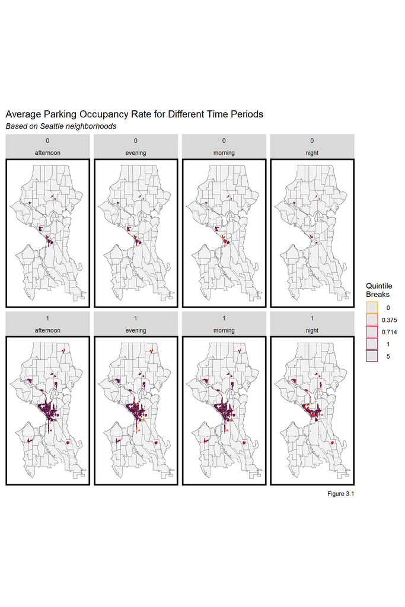

```r
ggplot() +
  geom_sf(data=neighborhoods,size =.1,color="grey40",alpha = .5) +
  geom_sf(data=parking_final,
          aes(color = q5(occupancy)),show.legend = TRUE, size = .5) +
  scale_colour_manual(values = palette5,
                      labels = qBr(parking_final, "occupancy",rnd = FALSE),
                      name = "Quintile\nBreaks") +
  facet_wrap(c('ifWeekday','timeperiod'),ncol = 4) +
  labs(title = "Average Parking Occupancy Rate for Different Time Periods",
       subtitle = "Based on Seattle neighborhoods",
       caption = "Figure 3.1") +
  mapTheme()
```

### 3.1.2 - Independent Variables

#### 3.1.2.1 - Population density at block group level

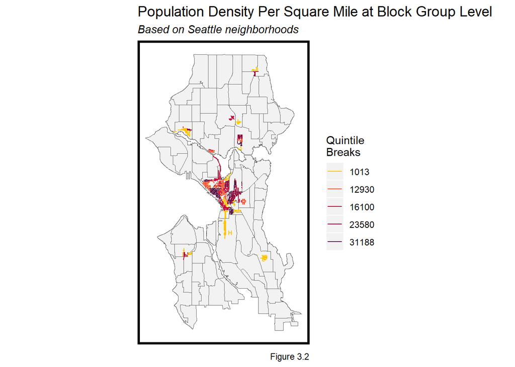

```r
ggplot() +
  geom_sf(data=neighborhoods,size =.1,color="grey40",alpha = .5) +
  geom_sf(data=parking_final,
          aes(color = q5(pop_dens)), show.legend = 'line', size = .5) +
  scale_colour_manual(values = palette5,
                      labels = qBr(parking_final, "pop_dens"),
                      name = "Quintile\nBreaks") +
  labs(title = "Population Density Per Square Mile at Block Group Level",
       subtitle = "Based on Seattle neighborhoods",
       caption = "Figure 3.2") +
  mapTheme()
```

#### 3.1.2.2 - Distance to the nearest bus stop

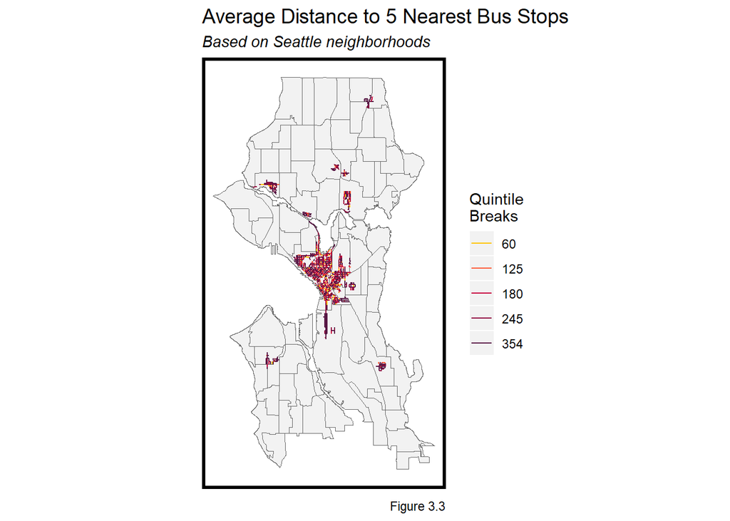

```r
ggplot() +
  geom_sf(data=neighborhoods,size =.1,color="grey40",alpha = .5) +
  geom_sf(data=parking_final,
          aes(color = q5(busStop_nn5)), show.legend = 'line', size = .5) +
  scale_colour_manual(values = palette5,
                      labels = qBr(parking_final, "busStop_nn5"),
                      name = "Quintile\nBreaks") +
  labs(title = "Average Distance to 5 Nearest Bus Stops",
       subtitle = "Based on Seattle neighborhoods",
       caption = "Figure 3.3") +
  mapTheme()
```

## 3.2 - Plots

### 3.2.1 - Histogram

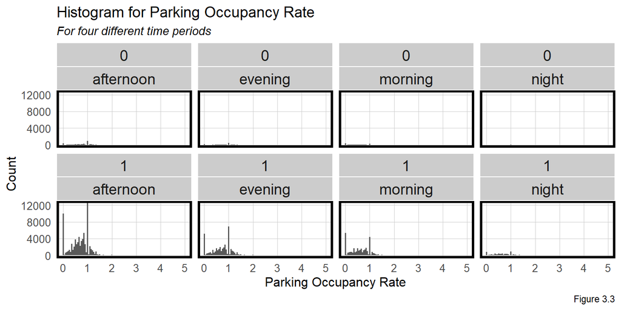

```r
ggplot(parking_final%>%
       st_set_geometry(NULL),aes(x=occupancy)) +
  geom_histogram(binwidth = .05) +
  facet_wrap(c('ifWeekday','timeperiod'),ncol=4) +
  labs(title = "Histogram for Parking Occupancy Rate",
       subtitle = "For four different time periods",
       x = "Parking Occupancy Rate",
       y = "Count",
       caption = "Figure 3.3") +
  plotTheme()
```

### 3.2.2 - Scatterplots

#### 3.2.2.1 - Percentage of family with 2 or more vehicles at block group level

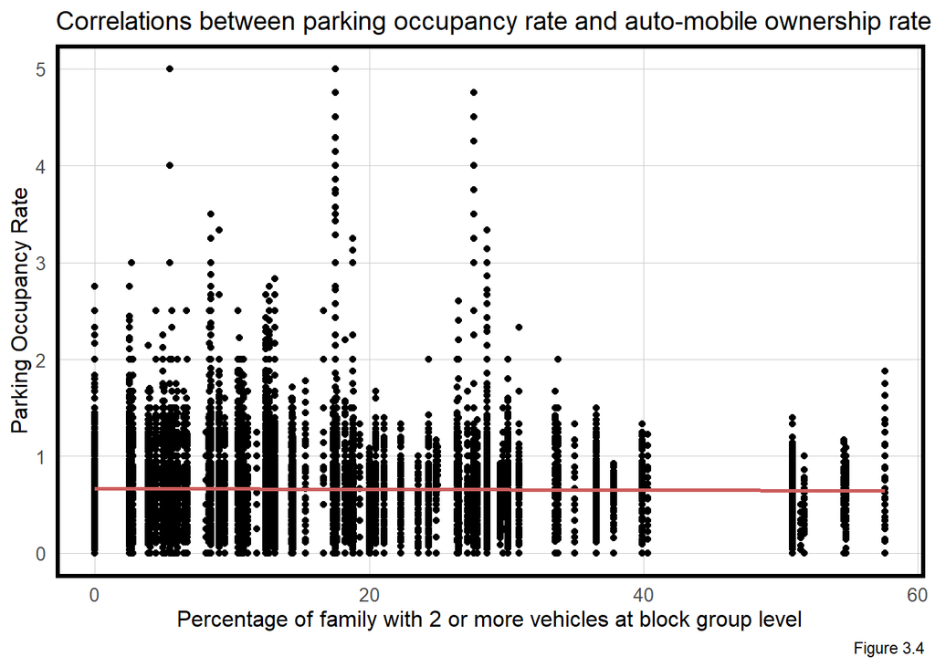

```r
parking_final %>%
  dplyr::select(pct_2vehmore, occupancy) %>%
  st_set_geometry(NULL) %>%
  ggplot(aes(pct_2vehmore, occupancy)) +
  geom_point() +
  geom_smooth(method = "lm", se=F, colour = "#CD5C5C") +
  labs(title = "Correlations between parking occupancy rate and auto-mobile ownership rate",
       x="Percentage of family with 2 or more vehicles at block group level",
       y="Parking Occupancy Rate",
       caption = "Figure 3.4") +
  plotTheme()
```

From the correlation plot, it’s hard to tell if there is relationship between parking occupancy rate and auto-mobile ownership rate. One of the most important reasons is that parking is not solely related to residents’ profile. In other words, people who work, shop, or even work in a certain place can impact the parking demand there. However, ACS data often represents the demographic profile of the residents in a cretain area. However, we’ll still include the auto-mobile ownership indicators in the regression model to see how they perform.

#### 3.2.2.2 - Time Lag

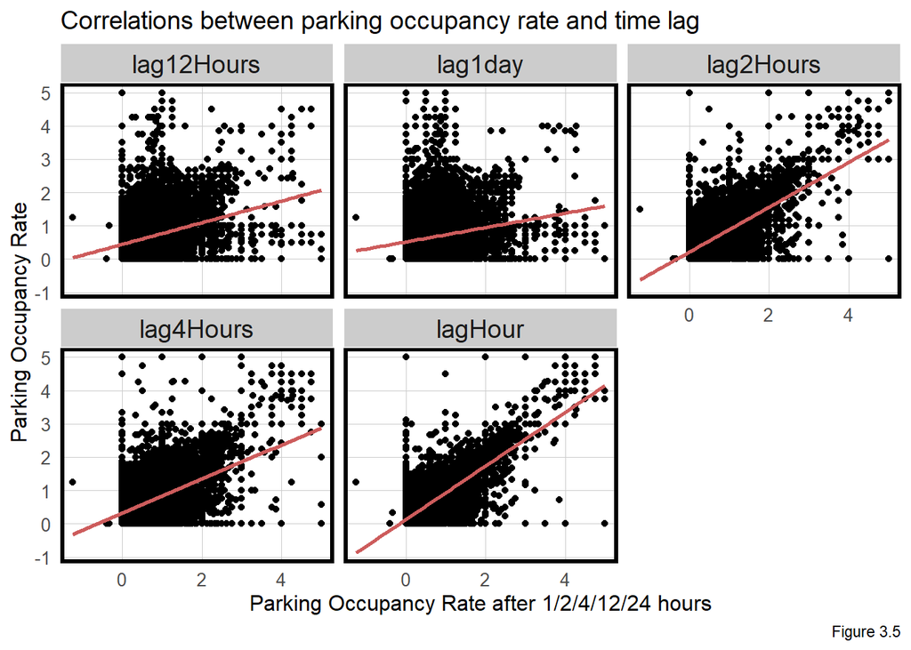

```r
parking_final %>%
  dplyr::select(starts_with('lag'), occupancy) %>%
  st_set_geometry(NULL) %>%
  gather(-occupancy, key = 'LagType', value = 'LagValue')%>%
  ggplot(aes(LagValue, occupancy)) +
  geom_point() +
  geom_smooth(method = "lm", se=F, colour = "#CD5C5C") +
  facet_wrap(~LagType)+
  labs(title = "Correlations between parking occupancy rate and time lag",
       x="Parking Occupancy Rate after 1/2/4/12/24 hours",
       y="Parking Occupancy Rate",
       caption = "Figure 3.5") +
  plotTheme()
```

As parking demand is significantly influenced by time segment, time lag becomes extraordinarily important in our model. From the scatterplots, we can conclude that all the time lags are significantly related to the parking occupancy rate. The only difference is how much they relates to each other. The time lag of one hour has the strongest correlation with parking demand, indicating that it is highly possible that lagHour can become a robust predictor in the regression model. Compared to other time lags, lag1day has the weakiest correlation with parking occupancy rate, which is acceptable because it is part of time lag’s nature.

#### 3.2.2.4 - Spatial Lag

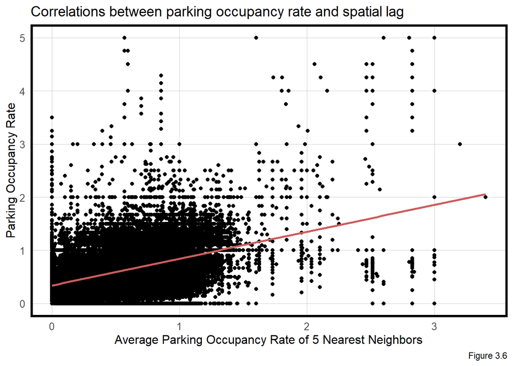

```r
parking_final %>%
  dplyr::select(SpatialLag_5NB, occupancy) %>%
  st_set_geometry(NULL) %>%
  ggplot(aes(SpatialLag_5NB, occupancy)) +
  geom_point() +
  geom_smooth(method = "lm", se=F, colour = "#CD5C5C") +
  labs(title = "Correlations between parking occupancy rate and spatial lag",
       x="Average Parking Occupancy Rate of 5 Nearest Neighbors",
       y="Parking Occupancy Rate",
       caption = "Figure 3.6") +
  plotTheme()
```

Spatial lag is another strong indicator in our model as shown in Figure 3.6. The spatial lag of 5 nearest neighbors during the same time period can help explain part of the current parking occupancy rate. We’ll include spatial lag into our regression model for more details.

### 3.2.3 - Correlation Plot

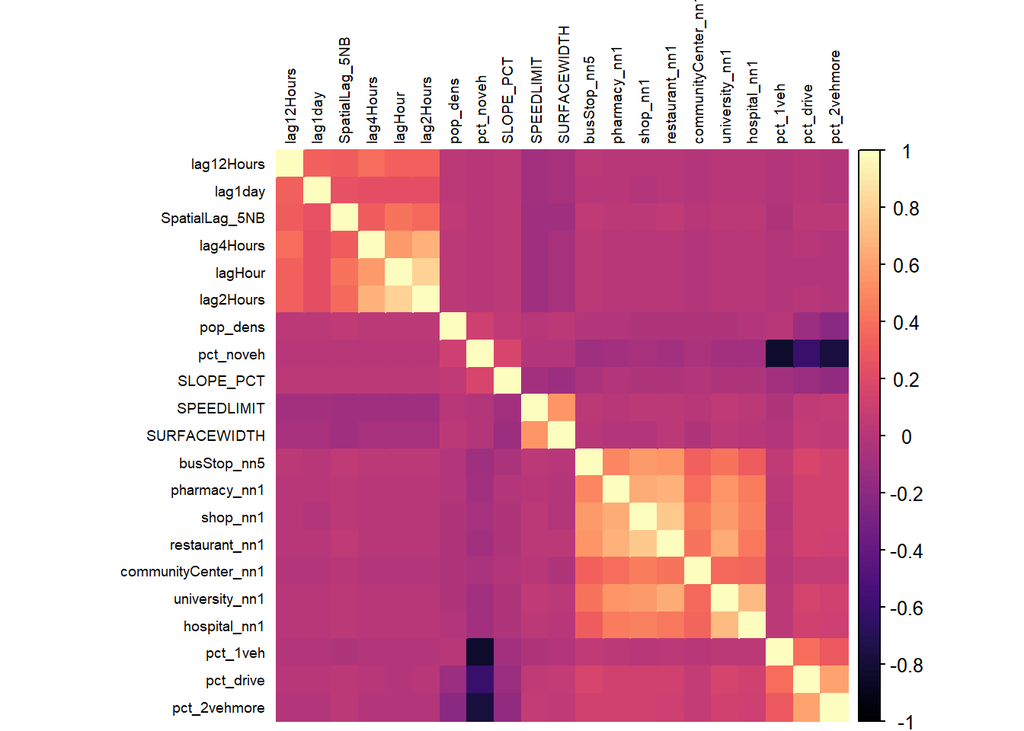

```r
Cor <-
  parking_final %>%
  st_set_geometry(NULL)%>%
  dplyr::select(shop_nn1,restaurant_nn1,busStop_nn5,pop_dens,pct_drive,
                pct_noveh,pct_1veh,pct_2vehmore,SPEEDLIMIT,SURFACEWIDTH,SLOPE_PCT,
                university_nn1,hospital_nn1,pharmacy_nn1,communityCenter_nn1,
                SpatialLag_5NB,lagHour,lag2Hours,lag4Hours,lag12Hours,lag1day
)

M <- cor(Cor)
corrplot(M, method = "color",order = "hclust",tl.col = "black",col = viridis::magma(100),tl.cex = .6)
```

According to the correlation plot, pct_noveh, pct_1veh, pct_2vehmore, and pct_drive are strongly related to each other.Meanwhile, as lagHour and lag2Hours have high correlation, compared to other spatial or time lag. To avoid multicollinearity, we eliminated pct_noveh, pct_1veh, and lag2Hours from the model.

# 4 - Methods

## 4.1 Space-time Process

```r
# Create a 70% train set
inTrain <- createDataPartition(
  y = paste(parking_final$nhood,parking_final$landuse,parking_final$timeperiod,parking_final$ifWeekday,parking_final$zoning),
  p = 0.70, list = FALSE)
train_set <- parking_final[inTrain,]
test_set <- parking_final[-inTrain,]
```

### 4.2.2 - Initial Model

The initial regression model eliminated the independent variables excluded in the correlation plot part. Model coefficients and summary statistics are presented as follows.

```r
reg1 <- lm(occupancy ~ ., data = (train_set%>%
                                    st_set_geometry(NULL))%>%
             dplyr::select(occupancy,shop_nn1,restaurant_nn1,busStop_nn5,nhood,pop_dens,pct_drive,
                           pct_2vehmore,timeperiod,ifWeekday,landuse,zoning,
                           university_nn1,hospital_nn1,pharmacy_nn1,communityCenter_nn1,SPEEDLIMIT,ONEWAY,SURFACEWIDTH,
                           SLOPE_PCT,SIDE,SpatialLag_5NB,lagHour,lag4Hours,lag12Hours,lag1day,
                           ARTDESCRIPT))
summary(reg1)
```

```r
reg_sum <- tidy(reg1)
#add significance level
reg_sum <- reg_sum %>%
  mutate(sig.level = ifelse(p.value>=1,"",
                            ifelse(p.value>=0.1&p.value<1,".",
                                   ifelse(p.value>=0.05&p.value<0.1,"*",
                                          ifelse(p.value<0.05&p.value>=0.01,"**","***")))))
kable(reg_sum,align="c",caption = "Table 4.1, Model Summary - Initial Model") %>%
  kable_styling(bootstrap_options = c("striped", "hover"))%>%
  row_spec(0,bold = T, color = "white", background = "#CD5C5C")%>%
  scroll_box(width = "100%", height = "400px")
```

Table 4.1, Model Summary - Initial Model

term

estimate

std.error

statistic

p.value

sig.level

(Intercept)

0.0051686

0.0270576

0.1910202

0.8485101

.

shop_nn1

0.0000015

0.0000020

0.7656128

0.4439084

.

restaurant_nn1

-0.0000024

0.0000017

-1.4067830

0.1594945

.

busStop_nn5

0.0000053

0.0000042

1.2668698

0.2052045

.

nhoodCapitol Hill

0.0159226

0.0062411

2.5512678

0.0107345

nhoodCascade

0.0532314

0.0171289

3.1076875

0.0018860

***

nhoodCentral Area

0.0100918

0.0114492

0.8814414

0.3780809

.

nhoodDowntown

0.0261724

0.0066690

3.9245056

0.0000870

***

nhoodFremont

-0.0141784

0.0083617

-1.6956393

0.0899570

nhoodGreen Lake

0.0271306

0.0100915

2.6884474

0.0071796

***

nhoodIndustrial District

-0.0404012

0.0315162

-1.2819174

0.1998743

.

nhoodLake City

-0.0270886

0.0140845

-1.9232924

0.0544459

nhoodQueen Anne

0.0181958

0.0147474

1.2338321

0.2172681

.

nhoodRainier Valley

0.0042413

0.0130051

0.3261298

0.7443268

.

nhoodRoosevelt

-0.0153724

0.0087481

-1.7572356

0.0788804

nhoodUniversity District

0.0095309

0.0123890

0.7693045

0.4417142

.

nhoodWest Seattle

0.0107823

0.0135610

0.7950975

0.4265585

.

pop_dens

0.0000001

0.0000001

0.8448808

0.3981792

.

pct_drive

-0.0001499

0.0001345

-1.1151182

0.2648022

.

pct_2vehmore

-0.0001527

0.0001608

-0.9501784

0.3420237

.

timeperiodevening

0.0225248

0.0017576

12.8159264

0.0000000

***

timeperiodmorning

-0.0031971

0.0018800

-1.7005910

0.0890226

timeperiodnight

-0.0695156

0.0035562

-19.5477285

0.0000000

***

ifWeekday1

-0.0085199

0.0035347

-2.4103460

0.0159390

landuseIndustrial

0.0814286

0.0397180

2.0501709

0.0403501

landuseMajor Institutions

0.0667823

0.0348682

1.9152770

0.0554597

landuseMixed

0.0436618

0.0270008

1.6170527

0.1058697

.

landuseResidential

0.0532668

0.0237690

2.2410258

0.0250264

zoningC1-75 (M)

0.0457734

0.0349441

1.3099059

0.1902304

.

zoningC2-40

0.0186054

0.0262861

0.7078016

0.4790700

.

zoningC2-55 (M)

-0.0146646

0.0357320

-0.4104058

0.6815091

.

zoningC2-75 (M)

-0.0001331

0.0765574

-0.0017384

0.9986130

.

zoningDH1/45

-0.0470896

0.0236636

-1.9899543

0.0465984

zoningDH2/55

-0.0913978

0.0712587

-1.2826204

0.1996278

.

zoningDMC-145

-0.0420971

0.0238690

-1.7636747

0.0777895

zoningDMC-170

-0.0240416

0.0197062

-1.2200052

0.2224655

.

zoningDMC-75

-0.0337608

0.0219584

-1.5374927

0.1241755

.

zoningDMC-95

-0.0407841

0.0223599

-1.8239822

0.0681574

zoningDMC 240/290-440

-0.0127132

0.0191669

-0.6632885

0.5071472

.

zoningDMC 340/290-440

-0.0179268

0.0194497

-0.9217035

0.3566852

.

zoningDMC 85/75-170

-0.0285747

0.0431154

-0.6627492

0.5074926

.

zoningDMR/C 145/75

-0.0312326

0.0203412

-1.5354300

0.1246811

.

zoningDMR/C 280/125

-0.0183134

0.0201272

-0.9098814

0.3628870

.

zoningDMR/C 75/75-170

-0.0526688

0.0279582

-1.8838453

0.0595885

zoningDMR/C 75/75-95

-0.0704250

0.0268359

-2.6242800

0.0086844

***

zoningDMR/C 95/75

-0.0059622

0.0220899

-0.2699066

0.7872326

.

zoningDMR/R 145/65

-0.0183544

0.0199191

-0.9214474

0.3568189

.

zoningDMR/R 280/65

-0.0115140

0.0208595

-0.5519806

0.5809628

.

zoningDMR/R 95/65

-0.0110913

0.0199529

-0.5558721

0.5782994

.

zoningDOC1 U/450-U

-0.0143011

0.0193143

-0.7404390

0.4590352

.

zoningDOC2 500/300-550

-0.0103834

0.0193737

-0.5359531

0.5919920

.

zoningDRC 85-170

-0.0304723

0.0209561

-1.4541007

0.1459212

.

zoningHR (M)

-0.0083909

0.0144209

-0.5818548

0.5606656

.

zoningIB U/45

-0.0248947

0.0390640

-0.6372784

0.5239448

.

zoningIB U/65

-0.0012303

0.0404350

-0.0304272

0.9757264

.

zoningIC-65 (M)

-0.0252933

0.0333234

-0.7590241

0.4478397

.

zoningIC-85 (M)

0.0391329

0.0284762

1.3742304

0.1693729

.

zoningIDM-65-150

-0.0895608

0.0259288

-3.4541067

0.0005523

***

zoningIDM-75-85

-0.0241030

0.0187698

-1.2841365

0.1990969

.

zoningIDM 85/85-170

-0.0312940

0.0189997

-1.6470808

0.0995443

zoningIDR 170

-0.0315307

0.0206568

-1.5264049

0.1269119

.

zoningIDR 45/125-270

-0.0607288

0.0282152

-2.1523462

0.0313722

zoningIDR/C 125/150-270

-0.0355347

0.0291827

-1.2176647

0.2233540

.

zoningIG1 U/85

-0.0050234

0.0224714

-0.2235443

0.8231123

.

zoningIG2 U/65

-0.0084652

0.0358055

-0.2364221

0.8131056

.

zoningLR1 (M)

-0.0290660

0.0442169

-0.6573503

0.5109571

.

zoningLR1 (M1)

0.0763674

0.0703704

1.0852203

0.2778264

.

zoningLR2

0.0401317

0.0543398

0.7385329

0.4601922

.

zoningLR2 (M)

0.0209848

0.0381603

0.5499130

0.5823801

.

zoningLR3

-0.0038605

0.0249058

-0.1550052

0.8768175

.

zoningLR3 (M)

0.0032180

0.0153018

0.2103048

0.8334302

.

zoningLR3 (M1)

0.0326271

0.0236558

1.3792404

0.1678234

.

zoningLR3 RC (M)

-0.0186098

0.0223684

-0.8319699

0.4054277

.

zoningMIO-105-C2-75 (M)

0.0970285

0.0390459

2.4849876

0.0129571

zoningMIO-105-LR3 (M)

-0.0014344

0.0332517

-0.0431384

0.9655913

.

zoningMIO-105-MR (M)

-0.0355447

0.0291539

-1.2192099

0.2227671

.

zoningMIO-105-NC2-55 (M)

-0.0081729

0.0773593

-0.1056488

0.9158612

.

zoningMIO-105-NC2P-55 (M)

0.1335109

0.0604933

2.2070364

0.0273135

zoningMIO-105-NC3-75 (M)

-0.0381187

0.0377922

-1.0086402

0.3131494

.

zoningMIO-105-NC3-95 (M)

-0.0310895

0.0345853

-0.8989221

0.3686961

.

zoningMIO-105-NC3P-55 (M)

-0.0201222

0.0313011

-0.6428587

0.5203171

.

zoningMIO-105-NC3P-75 (M)

-0.0060061

0.0315125

-0.1905953

0.8488431

.

zoningMIO-160-C1-55 (M)

0.0182013

0.0518119

0.3512958

0.7253671

.

zoningMIO-160-HR (M)

-0.0351286

0.0304124

-1.1550762

0.2480617

.

zoningMIO-160-LR3 (M)

-0.1152425

0.0477730

-2.4122924

0.0158542

zoningMIO-160-NC3-200 (M)

-0.0293418

0.0326469

-0.8987634

0.3687807

.

zoningMIO-160-NC3-75 (M)

-0.1847024

0.0753087

-2.4526049

0.0141841

zoningMIO-160-SF 5000

0.0243247

0.0476435

0.5105554

0.6096634

.

zoningMIO-200-HR (M)

0.0087942

0.0347824

0.2528355

0.8003958

.

zoningMIO-200-NC3-75 (M)

0.0548601

0.0376188

1.4583171

0.1447560

.

zoningMIO-240-HR (M)

-0.0167679

0.0290444

-0.5773195

0.5637248

.

zoningMIO-240-MR (M)

-0.0247835

0.0333167

-0.7438739

0.4569544

.

zoningMIO-240-NC3-75 (M)

-0.0570808

0.0361732

-1.5779846

0.1145720

.

zoningMIO-37-C1-55 (M)

-0.0631265

0.0354486

-1.7807918

0.0749492

zoningMIO-37-IC-65 (M)

-0.0022890

0.0433041

-0.0528595

0.9578440

.

zoningMIO-37-SF 5000

-0.0870291

0.0531941

-1.6360666

0.1018285

.

zoningMIO-65-LR3 (M)

-0.0099822

0.0348593

-0.2863558

0.7746061

.

zoningMIO-65-MR (M)

-0.0048236

0.0359418

-0.1342059

0.8932400

.

zoningMIO-65-NC2-55 (M)

0.0058887

0.0572755

0.1028129

0.9181117

.

zoningMIO-65-NC2P-55 (M)

-0.0122828

0.0340076

-0.3611789

0.7179664

.

zoningMIO-65-NC2P-75 (M)

-0.0679707

0.0394166

-1.7244190

0.0846350

zoningMIO-65-NC3-75 (M)

-0.0249343

0.0342545

-0.7279132

0.4666683

.

zoningMIO-65-NC3-95 (M)

-0.0111482

0.0333054

-0.3347255

0.7378328

.

zoningMIO-65-NC3P-75 (M)

0.1134008

0.0388692

2.9174970

0.0035292

***

zoningMIO-65-SF 5000

-0.0357581

0.0524771

-0.6814045

0.4956170

.

zoningMIO-70-MR (M)

-0.0250759

0.0396930

-0.6317449

0.5275549

.

zoningMIO-70-NC3P-200 (M)

-0.0564309

0.0306199

-1.8429501

0.0653390

zoningMPC-YT

0.0046187

0.0223339

0.2068045

0.8361629

.

zoningMR (M)

0.0233445

0.0145833

1.6007667

0.1094314

.

zoningMR (M1)

-0.0143344

0.0186756

-0.7675472

0.4427579

.

zoningMR RC (M)

0.0715364

0.0250349

2.8574655

0.0042712

***

zoningNC1-55 (M)

0.0081780

0.0757578

0.1079489

0.9140364

.

zoningNC1-65 (M1)

0.0366061

0.0758731

0.4824645

0.6294770

.

zoningNC1P-55 (M1)

0.0058730

0.0440768

0.1332458

0.8939992

.

zoningNC2-40

0.0541018

0.0324771

1.6658455

0.0957470

zoningNC2-55 (M)

0.0249587

0.0296049

0.8430589

0.3991973

.

zoningNC2-65

0.0704771

0.0308977

2.2809863

0.0225511

zoningNC2-75 (M)

0.0317666

0.0273542

1.1613092

0.2455187

.

zoningNC2-75 (M1)

0.0291857

0.0252363

1.1564995

0.2474794

.

zoningNC2P-55 (M)

0.0464058

0.0269629

1.7211002

0.0852354

zoningNC2P-65

0.0660845

0.0212575

3.1087626

0.0018792

***

zoningNC2P-75 (M)

0.0446170

0.0228727

1.9506684

0.0510990

zoningNC2P-75 (M1)

0.0365603

0.0221594

1.6498766

0.0989710

zoningNC3-200 (M)

0.0375139

0.0223656

1.6773068

0.0934853

zoningNC3-40

0.0400752

0.0228657

1.7526311

0.0796681

zoningNC3-55 (M)

0.0575133

0.0293758

1.9578505

0.0502501

zoningNC3-65

0.0523901

0.0230415

2.2737291

0.0229842

zoningNC3-75 (M)

0.0504121

0.0212364

2.3738519

0.0176053

zoningNC3-75 (M1)

0.0578484

0.0228761

2.5287695

0.0114477

zoningNC3-75 (M2)

0.0661325

0.0326422

2.0259814

0.0427691

zoningNC3-95 (M)

0.0452482

0.0386511

1.1706816

0.2417293

.

zoningNC3P-200 (M)

0.0217181

0.0238940

0.9089346

0.3633866

.

zoningNC3P-40

0.0432115

0.0269511

1.6033294

0.1088648

.

zoningNC3P-55 (M)

0.0434532

0.0270436

1.6067844

0.1081045

.

zoningNC3P-65

0.0465239

0.0233174

1.9952425

0.0460189

zoningNC3P-75 (M)

0.0597706

0.0202112

2.9573049

0.0031041

***

zoningNC3P-75 (M1)

0.0411947

0.0209749

1.9639965

0.0495330

zoningNC3P-95 (M)

0.0699534

0.0207912

3.3645644

0.0007669

***

zoningPMM-85

-0.0255505

0.0211482

-1.2081608

0.2269880

.

zoningPSM-100

-0.0381539

0.0204488

-1.8658205

0.0620691

zoningPSM-85-120

-0.0002417

0.0208872

-0.0115719

0.9907672

.

zoningPSM 100/100-120

-0.0160047

0.0188215

-0.8503407

0.3951375

.

zoningPSM 100/100-130

-0.0260222

0.0199271

-1.3058717

0.1915989

.

zoningPSM 100/120-150

-0.0295118

0.0226247

-1.3044058

0.1920980

.

zoningRSL (M)

-0.0173694

0.0247082

-0.7029790

0.4820703

.

zoningSM-SLU 100/65-145

-0.0056066

0.0299493

-0.1872045

0.8515006

.

zoningSM-SLU 100/95

-0.0467065

0.0200229

-2.3326522

0.0196682

zoningSM-SLU 145

-0.0441149

0.0205652

-2.1451246

0.0319450

zoningSM-SLU 175/85-280

-0.0482556

0.0195450

-2.4689523

0.0135524

zoningSM-SLU 240/125-440

-0.0242339

0.0204609

-1.1843999

0.2362573

.

zoningSM-SLU 85-280

-0.0650054

0.0209728

-3.0995125

0.0019389

***

zoningSM-SLU 85/65-160

-0.0419036

0.0236374

-1.7727660

0.0762702

zoningSM-SLU/R 65/95

-0.0071894

0.0199299

-0.3607351

0.7182982

.

zoningSM-U 75-240 (M1)

-0.0192051

0.0221354

-0.8676153

0.3856068

.

zoningSM-U 85

0.0260827

0.0299203

0.8717395

0.3833524

.

zoningSM-U 95-320 (M1)

-0.0050658

0.0223538

-0.2266208

0.8207190

.

zoningSM-U/R 75-240 (M1)

-0.0288213

0.0278568

-1.0346232

0.3008472

.

zoningSM-UP 160 (M)

-0.0505477

0.0200867

-2.5164799

0.0118548

zoningSM-UP 65

-0.0153826

0.0182781

-0.8415850

0.4000221

.

zoningSM-UP 65 (M)

-0.0207969

0.0146859

-1.4161146

0.1567447

.

zoningSM-UP 65 (M1)

-0.0089331

0.0231881

-0.3852451

0.7000565

.

zoningSM-UP 85

-0.0072226

0.0510061

-0.1416035

0.8873934

.

zoningSM-UP 85 (M)

-0.0159878

0.0116605

-1.3711110

0.1703431

.

zoningSM-UP 85 (M1)

-0.0160973

0.0119057

-1.3520620

0.1763582

.

university_nn1

-0.0000002

0.0000002

-0.8637679

0.3877173

.

hospital_nn1

0.0000004

0.0000003

1.2993326

0.1938325

.

pharmacy_nn1

0.0000009

0.0000007

1.2529051

0.2102429

.

communityCenter_nn1

-0.0000017

0.0000007

-2.5682625

0.0102223

SPEEDLIMIT

-0.0001451

0.0006275

-0.2312289

0.8171374

.

ONEWAYY

-0.0061808

0.0025780

-2.3974613

0.0165108

SURFACEWIDTH

0.0001178

0.0000580

2.0301009

0.0423487

SLOPE_PCT

0.0000187

0.0003177

0.0588764

0.9530506

.

SIDEN

0.0000655

0.0028365

0.0230774

0.9815886

.

SIDENE

-0.0052289

0.0044077

-1.1863222

0.2354976

.

SIDENW

-0.0088722

0.0048067

-1.8458028

0.0649235

SIDES

0.0018740

0.0028589

0.6554774

0.5121618

.

SIDESE

0.0032890

0.0046338

0.7097898

0.4778360

.

SIDESW

-0.0006522

0.0045127

-0.1445336

0.8850794

.

SIDEW

0.0063055

0.0026515

2.3780632

0.0174055

SpatialLag_5NB

0.1282682

0.0025241

50.8176309

0.0000000

***

lagHour

0.7107394

0.0022666

313.5640557

0.0000000

***

lag4Hours

0.0439817

0.0022239

19.7764334

0.0000000

***

lag12Hours

0.0392506

0.0019952

19.6727050

0.0000000

***

lag1day

0.0033875

0.0018853

1.7968063

0.0723691

ARTDESCRIPTMinor Arterial

0.0004431

0.0039426

0.1123809

0.9105216

.

ARTDESCRIPTNot Designated

0.0057480

0.0051949

1.1064657

0.2685274

.

ARTDESCRIPTPrincipal Arterial

-0.0005814

0.0041383

-0.1404825

0.8882790

.

Since the amenity distance indicators has little impact on parking occupancy, shown by the low coefficient estimates, we’ll further exclude shop_count,restaurant_count, university_nn1, hospital_nn1, pharmacy_nn1, busStop_nn5, and communityCentre_nn1 to check if the model makes any progress.

### 4.2.3 - Experiment Model

```r
reg2 <- lm(occupancy ~ ., data = (train_set%>%
                                    st_set_geometry(NULL))%>%
             dplyr::select(occupancy,nhood,pop_dens,pct_drive,
                           pct_2vehmore,timeperiod,ifWeekday,landuse,zoning,SPEEDLIMIT,ONEWAY,SURFACEWIDTH,
                           SLOPE_PCT,SIDE,SpatialLag_5NB,lagHour,lag4Hours,lag12Hours,lag1day,
                           ARTDESCRIPT))
summary(reg2)
```

```r
reg_sum2 <- tidy(reg2)
#add significance level
reg_sum2 <- reg_sum2 %>%
  mutate(sig.level = ifelse(p.value>=1,"",
                            ifelse(p.value>=0.1&p.value<1,".",
                                   ifelse(p.value>=0.05&p.value<0.1,"*",
                                          ifelse(p.value<0.05&p.value>=0.01,"**","***")))))
kable(reg_sum2,align="c",caption = "Table 4.2, Model Summary - Experiment Model") %>%
  kable_styling(bootstrap_options = c("striped", "hover"))%>%
  row_spec(0,bold = T, color = "white", background = "#CD5C5C")%>%
  scroll_box(width = "100%", height = "400px")
```

Table 4.2, Model Summary - Experiment Model

term

estimate

std.error

statistic

p.value

sig.level

(Intercept)

0.0011657

0.0270087

0.0431610

0.9655733

.

nhoodCapitol Hill

0.0157718

0.0062276

2.5325713

0.0113243

nhoodCascade

0.0531572

0.0171202

3.1049489

0.0019036

***

nhoodCentral Area

0.0100330

0.0113982

0.8802246

0.3787395

.

nhoodDowntown

0.0271671

0.0066420

4.0901899

0.0000431

***

nhoodFremont

-0.0141708

0.0083380

-1.6995383

0.0892206

nhoodGreen Lake

0.0253821

0.0100406

2.5279395

0.0114748

nhoodIndustrial District

-0.0398450

0.0314946

-1.2651356

0.2058254

.

nhoodLake City

-0.0272346

0.0140349

-1.9404826

0.0523236

nhoodQueen Anne

0.0181787

0.0147178

1.2351507

0.2167770

.

nhoodRainier Valley

0.0046619

0.0129647

0.3595821

0.7191603

.

nhoodRoosevelt

-0.0141534

0.0087160

-1.6238328

0.1044143

.

nhoodUniversity District

0.0098056

0.0123715

0.7925933

0.4280165

.

nhoodWest Seattle

0.0127437

0.0135163

0.9428391

0.3457652

.

pop_dens

0.0000001

0.0000001

0.8148722

0.4151472

.

pct_drive

-0.0001300

0.0001338

-0.9716043

0.3312496

.

pct_2vehmore

-0.0001661

0.0001604

-1.0353228

0.3005204

.

timeperiodevening

0.0225731

0.0017575

12.8438266

0.0000000

***

timeperiodmorning

-0.0032113

0.0018800

-1.7081435

0.0876125

timeperiodnight

-0.0695700

0.0035562

-19.5630643

0.0000000

***

ifWeekday1

-0.0086184

0.0035341

-2.4386471

0.0147439

landuseIndustrial

0.0813260

0.0396441

2.0514003

0.0402303

landuseMajor Institutions

0.0660384

0.0348240

1.8963457

0.0579169

landuseMixed

0.0447334

0.0269768

1.6582139

0.0972771

landuseResidential

0.0548203

0.0237365

2.3095323

0.0209159

zoningC1-75 (M)

0.0488088

0.0349087

1.3981829

0.1620609

.

zoningC2-40

0.0204359

0.0262595

0.7782288

0.4364358

.

zoningC2-55 (M)

-0.0111394

0.0356519

-0.3124491

0.7546998

.

zoningC2-75 (M)

0.0037309

0.0764969

0.0487719

0.9611012

.

zoningDH1/45

-0.0466629

0.0236470

-1.9733156

0.0484621

zoningDH2/55

-0.0937601

0.0712177

-1.3165280

0.1879996

.

zoningDMC-145

-0.0443918

0.0238348

-1.8624835

0.0625376

zoningDMC-170

-0.0244233

0.0196844

-1.2407465

0.2147020

.

zoningDMC-75

-0.0326127

0.0219020

-1.4890308

0.1364821

.

zoningDMC-95

-0.0428888

0.0222790

-1.9250752

0.0542225

zoningDMC 240/290-440

-0.0127827

0.0191358

-0.6679982

0.5041361

.

zoningDMC 340/290-440

-0.0182474

0.0193993

-0.9406256

0.3468988

.

zoningDMC 85/75-170

-0.0378994

0.0428146

-0.8852001

0.3760506

.

zoningDMR/C 145/75

-0.0315866

0.0202999

-1.5559937

0.1197124

.

zoningDMR/C 280/125

-0.0179193

0.0201016

-0.8914346

0.3726980

.

zoningDMR/C 75/75-170

-0.0541365

0.0278867

-1.9413002

0.0522244

zoningDMR/C 75/75-95

-0.0699630

0.0267250

-2.6178893

0.0088487

***

zoningDMR/C 95/75

-0.0057275

0.0220700

-0.2595152

0.7952382

.

zoningDMR/R 145/65

-0.0183275

0.0198739

-0.9221859

0.3564336

.

zoningDMR/R 280/65

-0.0100122

0.0208046

-0.4812483

0.6303409

.

zoningDMR/R 95/65

-0.0108569

0.0199042

-0.5454555

0.5854414

.

zoningDOC1 U/450-U

-0.0150240

0.0192785

-0.7793123

0.4357974

.

zoningDOC2 500/300-550

-0.0109660

0.0193432

-0.5669173

0.5707715

.

zoningDRC 85-170

-0.0315643

0.0209210

-1.5087367

0.1313689

.

zoningHR (M)

-0.0090516

0.0144048

-0.6283755

0.5297592

.

zoningIB U/45

-0.0233928

0.0390171

-0.5995531

0.5488053

.

zoningIB U/65

-0.0017450

0.0403735

-0.0432205

0.9655259

.

zoningIC-65 (M)

-0.0243276

0.0332831

-0.7309282

0.4648246

.

zoningIC-85 (M)

0.0404593

0.0284561

1.4218118

0.1550837

.

zoningIDM-65-150

-0.0907205

0.0258823

-3.5051221

0.0004566

***

zoningIDM-75-85

-0.0246307

0.0187500

-1.3136393

0.1889703

.

zoningIDM 85/85-170

-0.0323647

0.0189815

-1.7050711

0.0881840

zoningIDR 170

-0.0330347

0.0206458

-1.6000719

0.1095855

.

zoningIDR 45/125-270

-0.0614285

0.0282107

-2.1774918

0.0294460

zoningIDR/C 125/150-270

-0.0341944

0.0291105

-1.1746424

0.2401403

.

zoningIG1 U/85

-0.0033851

0.0224512

-0.1507766

0.8801523

.

zoningIG2 U/65

-0.0057331

0.0357541

-0.1603479

0.8726073

.

zoningLR1 (M)

-0.0323455

0.0440673

-0.7340020

0.4629490

.

zoningLR1 (M1)

0.0749240

0.0703350

1.0652449

0.2867674

.

zoningLR2

0.0380396

0.0542696

0.7009377

0.4833434

.

zoningLR2 (M)

0.0180560

0.0381253

0.4735961

0.6357889

.

zoningLR3

-0.0031836

0.0248803

-0.1279582

0.8981823

.

zoningLR3 (M)

0.0039989

0.0152758

0.2617827

0.7934894

.

zoningLR3 (M1)

0.0350820

0.0235755

1.4880717

0.1367348

.

zoningLR3 RC (M)

-0.0135447

0.0222804

-0.6079212

0.5432410

.

zoningMIO-105-C2-75 (M)

0.1002777

0.0390044

2.5709314

0.0101438

zoningMIO-105-LR3 (M)

0.0023161

0.0332315

0.0696947

0.9444368

.

zoningMIO-105-MR (M)

-0.0326330

0.0291135

-1.1208882

0.2623379

.

zoningMIO-105-NC2-55 (M)

-0.0134350

0.0772566

-0.1739016

0.8619431

.

zoningMIO-105-NC2P-55 (M)

0.1360614

0.0604412

2.2511376

0.0243788

zoningMIO-105-NC3-75 (M)

-0.0428975

0.0376414

-1.1396372

0.2544399

.

zoningMIO-105-NC3-95 (M)

-0.0302621

0.0345750

-0.8752616

0.3814334

.

zoningMIO-105-NC3P-55 (M)

-0.0160562

0.0312475

-0.5138395

0.6073652

.

zoningMIO-105-NC3P-75 (M)

-0.0049304

0.0314605

-0.1567172

0.8754680

.

zoningMIO-160-C1-55 (M)

0.0061014

0.0512946

0.1189483

0.9053165

.

zoningMIO-160-HR (M)

-0.0335651

0.0303991

-1.1041493

0.2695308

.

zoningMIO-160-LR3 (M)

-0.1123872

0.0476054

-2.3608059

0.0182370

zoningMIO-160-NC3-200 (M)

-0.0299705

0.0326408

-0.9181939

0.3585194

.

zoningMIO-160-NC3-75 (M)

-0.1812501

0.0752724

-2.4079210

0.0160453

zoningMIO-160-SF 5000

0.0297258

0.0475984

0.6245137

0.5322915

.

zoningMIO-200-HR (M)

0.0130284

0.0346757

0.3757196

0.7071261

.

zoningMIO-200-NC3-75 (M)

0.0543912

0.0375353

1.4490678

0.1473215

.

zoningMIO-240-HR (M)

-0.0156394

0.0290180

-0.5389534

0.5899201

.

zoningMIO-240-MR (M)

-0.0227606

0.0332570

-0.6843863

0.4937327

.

zoningMIO-240-NC3-75 (M)

-0.0569692

0.0361014

-1.5780327

0.1145609

.

zoningMIO-37-C1-55 (M)

-0.0603353

0.0354091

-1.7039485

0.0883935

zoningMIO-37-IC-65 (M)

0.0013620

0.0432681

0.0314779

0.9748885

.

zoningMIO-37-SF 5000

-0.0848916

0.0530262

-1.6009362

0.1093939

.

zoningMIO-65-LR3 (M)

-0.0055727

0.0348045

-0.1601130

0.8727923

.

zoningMIO-65-MR (M)

-0.0044050

0.0358825

-0.1227608

0.9022967

.

zoningMIO-65-NC2-55 (M)

0.0127619

0.0571776

0.2231984

0.8233815

.

zoningMIO-65-NC2P-55 (M)

-0.0105660

0.0339813

-0.3109346

0.7558509

.

zoningMIO-65-NC2P-75 (M)

-0.0636907

0.0393504

-1.6185512

0.1055467

.

zoningMIO-65-NC3-75 (M)

-0.0223443

0.0341882

-0.6535676

0.5133918

.

zoningMIO-65-NC3-95 (M)

-0.0092171

0.0332453

-0.2772462

0.7815916

.

zoningMIO-65-NC3P-75 (M)

0.1120004

0.0388234

2.8848651

0.0039166

***

zoningMIO-65-SF 5000

-0.0316722

0.0523790

-0.6046736

0.5453971

.

zoningMIO-70-MR (M)

-0.0255600

0.0396530

-0.6445925

0.5191927

.

zoningMIO-70-NC3P-200 (M)

-0.0545951

0.0305800

-1.7853189

0.0742123

zoningMPC-YT

0.0044728

0.0223162

0.2004300

0.8411447

.

zoningMR (M)

0.0218242

0.0145427

1.5006988

0.1334363

.

zoningMR (M1)

-0.0152600

0.0186526

-0.8181151

0.4132932

.

zoningMR RC (M)

0.0729897

0.0250209

2.9171527

0.0035331

***

zoningNC1-55 (M)

0.0100076

0.0757152

0.1321739

0.8948470

.

zoningNC1-65 (M1)

0.0386706

0.0757173

0.5107232

0.6095459

.

zoningNC1P-55 (M1)

0.0063147

0.0440118

0.1434764

0.8859142

.

zoningNC2-40

0.0546446

0.0324717

1.6828367

0.0924095

zoningNC2-55 (M)

0.0263164

0.0294710

0.8929621

0.3718794

.

zoningNC2-65

0.0715974

0.0308865

2.3180853

0.0204465

zoningNC2-75 (M)

0.0319346

0.0272909

1.1701529

0.2419419

.

zoningNC2-75 (M1)

0.0308939

0.0251998

1.2259583

0.2202170

.

zoningNC2P-55 (M)

0.0490071

0.0269190

1.8205404

0.0686794

zoningNC2P-65

0.0673767

0.0212323

3.1733103

0.0015075

***

zoningNC2P-75 (M)

0.0469549

0.0228385

2.0559558

0.0397891

zoningNC2P-75 (M1)

0.0383693

0.0221119

1.7352364

0.0827017

zoningNC3-200 (M)

0.0399734

0.0223131

1.7914765

0.0732196

zoningNC3-40

0.0415880

0.0228512

1.8199537

0.0687687

zoningNC3-55 (M)

0.0590616

0.0291960

2.0229320

0.0430825

zoningNC3-65

0.0530990

0.0230268

2.3059692

0.0211142

zoningNC3-75 (M)

0.0512070

0.0212155

2.4136571

0.0157949

zoningNC3-75 (M1)

0.0604040

0.0228174

2.6472788

0.0081154

***

zoningNC3-75 (M2)

0.0669786

0.0326212

2.0532260

0.0400530

zoningNC3-95 (M)

0.0436820

0.0386085

1.1314067

0.2578864

.

zoningNC3P-200 (M)

0.0232456

0.0238380

0.9751460

0.3294899

.

zoningNC3P-40

0.0442152

0.0269289

1.6419274

0.1006079

.

zoningNC3P-55 (M)

0.0445358

0.0270050

1.6491710

0.0991154

zoningNC3P-65

0.0483070

0.0233086

2.0724970

0.0382214

zoningNC3P-75 (M)

0.0609884

0.0201897

3.0207713

0.0025219

***

zoningNC3P-75 (M1)

0.0437573

0.0209482

2.0888315

0.0367252

zoningNC3P-95 (M)

0.0702041

0.0207596

3.3817684

0.0007205

***

zoningPMM-85

-0.0261091

0.0211097

-1.2368328

0.2161518

.

zoningPSM-100

-0.0387214

0.0204369

-1.8946809

0.0581373

zoningPSM-85-120

-0.0016939

0.0208342

-0.0813061

0.9351986

.

zoningPSM 100/100-120

-0.0164660

0.0187923

-0.8762103

0.3809176

.

zoningPSM 100/100-130

-0.0265279

0.0198910

-1.3336666

0.1823159

.

zoningPSM 100/120-150

-0.0292785

0.0226208

-1.2943154

0.1955592

.

zoningRSL (M)

-0.0170894

0.0246983

-0.6919276

0.4889842

.

zoningSM-SLU 100/65-145

-0.0062944

0.0299339

-0.2102749

0.8334535

.

zoningSM-SLU 100/95

-0.0460628

0.0199956

-2.3036471

0.0212443

zoningSM-SLU 145

-0.0445521

0.0205176

-2.1714093

0.0299023

zoningSM-SLU 175/85-280

-0.0472719

0.0195205

-2.4216562

0.0154515

zoningSM-SLU 240/125-440

-0.0231726

0.0204305

-1.1342162

0.2567063

.

zoningSM-SLU 85-280

-0.0655713

0.0209474

-3.1302878

0.0017468

***

zoningSM-SLU 85/65-160

-0.0413853

0.0236178

-1.7522922

0.0797263

zoningSM-SLU/R 65/95

-0.0063558

0.0199038

-0.3193271

0.7494791

.

zoningSM-U 75-240 (M1)

-0.0194005

0.0221121

-0.8773711

0.3802870

.

zoningSM-U 85

0.0228289

0.0298791

0.7640415

0.4448441

.

zoningSM-U 95-320 (M1)

-0.0043903

0.0223194

-0.1967034

0.8440600

.

zoningSM-U/R 75-240 (M1)

-0.0270524

0.0278329

-0.9719565

0.3310743

.

zoningSM-UP 160 (M)

-0.0492117

0.0200536

-2.4540026

0.0141291

zoningSM-UP 65

-0.0155850

0.0182723

-0.8529335

0.3936980

.

zoningSM-UP 65 (M)

-0.0203678

0.0146378

-1.3914530

0.1640909

.

zoningSM-UP 65 (M1)

-0.0071790

0.0231569

-0.3100161

0.7565493

.

zoningSM-UP 85

-0.0073587

0.0508753

-0.1446419

0.8849939

.

zoningSM-UP 85 (M)

-0.0169305

0.0116436

-1.4540611

0.1459322

.

zoningSM-UP 85 (M1)

-0.0155778

0.0118972

-1.3093581

0.1904158

.

SPEEDLIMIT

-0.0000863

0.0006266

-0.1377931

0.8904042

.

ONEWAYY

-0.0060035

0.0025745

-2.3318767

0.0197090

SURFACEWIDTH

0.0001224

0.0000579

2.1145710

0.0344687

SLOPE_PCT

0.0000598

0.0003169

0.1885698

0.8504303

.

SIDEN

0.0005486

0.0028212

0.1944684

0.8458095

.

SIDENE

-0.0048301

0.0043887

-1.1005862

0.2710792

.

SIDENW

-0.0087632

0.0047734

-1.8358298

0.0663855

SIDES

0.0021945

0.0028445

0.7714905

0.4404179

.

SIDESE

0.0032510

0.0045906

0.7081835

0.4788328

.

SIDESW

-0.0002937

0.0044867

-0.0654557

0.9478113

.

SIDEW

0.0068779

0.0026419

2.6034401

0.0092306

***

SpatialLag_5NB

0.1279330

0.0025185

50.7971068

0.0000000

***

lagHour

0.7108643

0.0022663

313.6677619

0.0000000

***

lag4Hours

0.0440374

0.0022238

19.8024310

0.0000000

***

lag12Hours

0.0393538

0.0019948

19.7278566

0.0000000

***

lag1day

0.0034996

0.0018848

1.8567200

0.0633536

ARTDESCRIPTMinor Arterial

-0.0003537

0.0039283

-0.0900452

0.9282514

.

ARTDESCRIPTNot Designated

0.0055382

0.0051820

1.0687348

0.2851915

.

ARTDESCRIPTPrincipal Arterial

-0.0014203

0.0041169

-0.3449844

0.7301067

.

For the little difference of R-sqaured between the experiment model and the initial model, it makes more sense to delete those amenity features from the initial model and keep the prediction model more clear. Although some predictors in the model show high p-values, indicating a low statistically significance level, we decided to keep those variables because they have relatively high coefficient estimates. Thus, the experiment model is our final regression model.  
From the model summary, the most important factor for the prediction model is, with no doubt, the one hour lag of parking occupancy rate. Such a finding exemplifies the fact that parking occupancy rate is sensitive to time. On the other hand, the statistical significance of spatial lag, land use type, zoning, and neighborhood indicators verifies the spatial pattern of parking demand exists in Seattle.  
Generally speaking, our method of space-time process successfully captures the characteristics and trends of parking demand in Seattle.

# 5 - Results

## 5.1 - Test Set Prediction

As we already built up the model, we can test the prediction accuracy of model on the test set by calculating the Mean Absolute Error (MAE) and Mean Absolute Percent Error (MAPE). Also, the Absolute Error histogram can help us understand the accuracy better.

```r
test_set <-
  test_set %>%
  mutate(occupancyPredict = predict(reg2, test_set),
         occupancyError = occupancy - occupancyPredict,
         occupancyAbsError = abs(occupancy - occupancyPredict),
         occupancyAPE = (abs(occupancy - occupancyPredict)) / occupancy)%>%
  filter(is.finite(occupancyAPE))

MAE.test <-  mean(test_set$occupancyAbsError, na.rm = TRUE)

MAPE.test <- mean(test_set$occupancyAPE * 100, na.rm = TRUE) %>%
  round(2) %>%
  paste("%")

error_sum = data_frame('R-squared' = summary(reg2)$r.squared,
                       'Adjusted R-squared' = summary(reg2)$adj.r.squared,
                       'MAE' = MAE.test,'MAPE'=MAPE.test)
```

```r
kable(error_sum,align="c",caption = "Table 5.1, Model Error Summary - Test Set") %>%
  kable_styling(bootstrap_options = c("striped", "hover"))%>%
  row_spec(0,bold = T, color = "white", background = "#CD5C5C")
```

Table 5.1, Model Error Summary - Test Set

| R-squared | Adjusted R-squared | MAE | MAPE |
| --- | --- | --- | --- |
| 0.6654337 | 0.6648961 | 0.1600527 | 29.68 % |

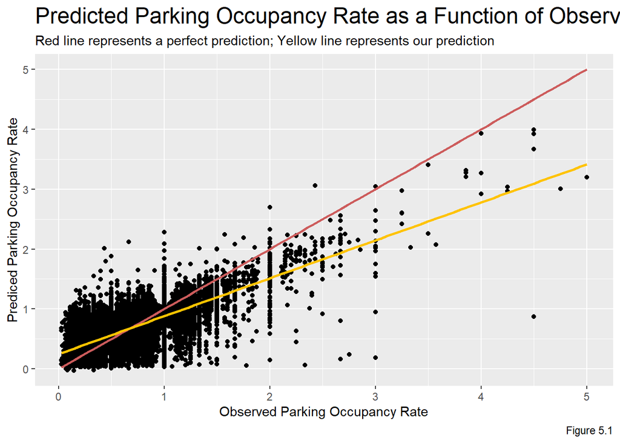

```r
ggplot(test_set, aes(occupancy, occupancyPredict)) +
  geom_point() +
  stat_smooth(data=test_set, aes(occupancy, occupancy),
              method = "lm", se = FALSE, size = 1, colour="#CD5C5C") +
  stat_smooth(data=test_set, aes(occupancy, occupancyPredict),
              method = "lm", se = FALSE, size = 1, colour="#FFC300") +
  labs(title="Predicted Parking Occupancy Rate as a Function of Observed Rate",
       subtitle="Red line represents a perfect prediction; Yellow line represents our prediction",
       x="Observed Parking Occupancy Rate", y="Prediced Parking Occupancy Rate",
       caption = "Figure 5.1") +
  theme(plot.title = element_text(size = 18,colour = "black"))
```

From the scatterplot showing the relationship between the predicted and observed parking occupancy rate, the model did a better job in predicting for those parking observations with an occupancy rate of 0.8. While the parking occupancy increases, the accuracy of prediction decreases.

## 5.2 - Full Set Prediction

```r
parking_final <-
  parking_final %>%
  mutate(occupancyPredict = predict(reg2, parking_final),
         occupancyError = occupancy - occupancyPredict,
         occupancyAbsError = abs(occupancy - occupancyPredict),
         occupancyAPE = (abs(occupancy - occupancyPredict)) / occupancy)%>%
  filter(is.finite(occupancyAPE))

MAE.test2 <-  mean(parking_final$occupancyAbsError, na.rm = TRUE)

MAPE.test2 <- mean(parking_final$occupancyAPE * 100, na.rm = TRUE) %>%
  round(2) %>%
  paste("%")

error_sum2 = data_frame('R-squared' = summary(reg1)$r.squared,
                       'Adjusted R-squared' = summary(reg1)$adj.r.squared,
                       'MAE' = MAE.test2,'MAPE'=MAPE.test2)
```

```r
kable(error_sum2,align="c",caption = "Table 5.2, Model Error Summary - Full Set") %>%
  kable_styling(bootstrap_options = c("striped", "hover"))%>%
  row_spec(0,bold = T, color = "white", background = "#CD5C5C")
```

Table 5.2, Model Error Summary - Full Set

| R-squared | Adjusted R-squared | MAE | MAPE |
| --- | --- | --- | --- |
| 0.6654709 | 0.6649123 | 0.1596302 | 29.55 % |

From the prediction error and model statistics of the full set prediction, our model can capture 66.51% of the parking occupancy rate variance. The average difference between the predicted and actual parking occupancy rate is roughly 0.16 (MAE) or 29.5% (MAPE).

## 5.3 - 100-Fold Cross Validation

To test the general accuracy level and generalizability of our prediction model, we used k-fold cross-validation. K-fold cross-validation is a commonly used cross validation method for linear regression model.

```r
detach(package:papeR)
# specify the number of k-fold partitions
fitControl <- trainControl(method = "cv", number = 100)

# begin the validation
set.seed(825)

reg2.cv <- train(occupancy ~ ., data = (train_set%>%
                                    st_set_geometry(NULL))%>%
                   dplyr::select(occupancy,nhood,pop_dens,pct_drive,
                           pct_2vehmore,timeperiod,ifWeekday,landuse,zoning,
                           SPEEDLIMIT,ONEWAY,SURFACEWIDTH,
                           SLOPE_PCT,SIDE,SpatialLag_5NB,lagHour,lag4Hours,lag12Hours,lag1day,
                           ARTDESCRIPT),
                 method = "lm", trControl = fitControl, na.action = na.pass)


# mean MAE
mean(reg2.cv$resample[,3])

# standard deviation of MAE
sd(reg2.cv$resample[,3])
```

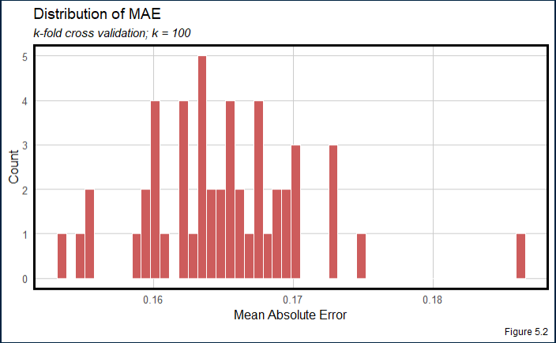

```r
# plot the MAE histogram
ggplot(as.data.frame(reg2.cv$resample), aes(MAE)) +
  geom_histogram(bins = 50, colour="white", fill = "#CD5C5C") +
  labs(title="Distribution of MAE", subtitle = "k-fold cross validation; k = 100",
       x="Mean Absolute Error", y="Count",
       caption = "Figure 5.2") +
  plotTheme()
```

After running the 100-fold crass validation, the result of each fold is normally distributed, as shown in the MAE histogram. Although the distribution of MAE is not perfectly normal, most of the folds have an MAE between 0.16 and 0.17, which is an acceptable variance range for a 100-fold cross-validation. In other words, our prediction model performs similarly across different data sets, in terms of prediction errors.

# 6 - Generalizability

Although the k-fold cross-validation above demonstrated the overall generalizability level of our model for different sets of data, we still do not know whether the model does a good job in predicting across all neighborhoods and during all timeperiods. We choose to verify generalizability from the perspectives of neighborhoos and time periods because our regression model shows the spatial-temporal trend of parking demand across Seattle. A good prediction model shall be able to predict similarly, in terms of prediction error, for any spatial location or time period.

## 6.1 - Prediction across Neighborhoods

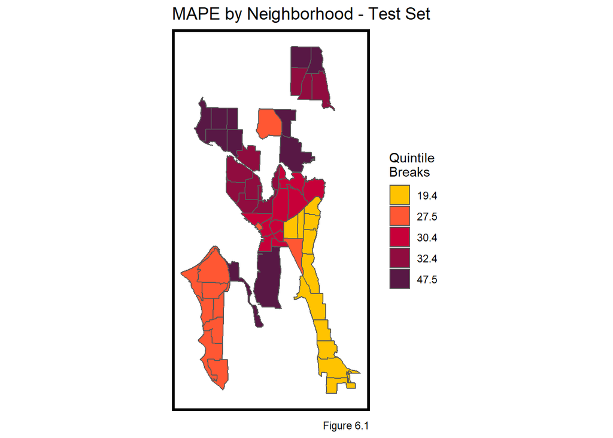

```r
detach(package:papeR)
ggplot() +
geom_sf(data = test_set%>%
          st_set_geometry(NULL)%>%
          group_by(nhood)%>%
          summarize(MAPE = mean(occupancyAPE)*100)%>%
          left_join(neighborhoods)%>%
          st_as_sf()%>%
          st_transform(2285), aes(fill = q5(MAPE))) +
  scale_fill_manual(values = palette5,
                    labels = qBr(test_set%>%group_by(nhood)%>%summarize(MAPE = mean(occupancyAPE)*100), "MAPE", rnd = F),
                    name="Quintile\nBreaks") +
  labs(title = "MAPE by Neighborhood - Test Set",
       caption = "Figure 6.1") +
  mapTheme()
```

```r
detach(package:papeR)
geneNhood <- test_set%>%
          group_by(nhood)%>%
          summarize(MAPE = mean(occupancyAPE)*100)%>%
          st_set_geometry(NULL)
kable(geneNhood,align="c",caption = "Table 6.1, MAPE by Neighborhood - Test Set") %>%
  kable_styling(bootstrap_options = c("striped", "hover"))%>%
  row_spec(0,bold = T, color = "white", background = "#CD5C5C")%>%
  scroll_box(width = "100%", height = "200px")
```

Table 6.1, MAPE by Neighborhood - Test Set

| nhood | MAPE |
| --- | --- |
| Ballard | 33.22192 |
| Capitol Hill | 29.51219 |
| Cascade | 31.21770 |
| Central Area | 25.72131 |
| Downtown | 28.53212 |
| Fremont | 29.70957 |
| Green Lake | 26.88005 |
| Industrial District | 47.49974 |
| Lake City | 31.39931 |
| Queen Anne | 31.08608 |
| Rainier Valley | 19.36324 |
| Roosevelt | 34.08339 |
| University District | 32.76231 |
| West Seattle | 27.21882 |

## 6.2 - Prediction across Timeperiods

```r
detach(package:papeR)
geneTime <- test_set %>%
  group_by(timeperiod) %>%
  summarize(MAPE = mean(occupancyAPE, na.rm = T)*100)%>%
  st_set_geometry(NULL)
```

```r
detach(package:papeR)
kable(geneTime,align="c",caption = "Table 6.2, MAPE by Timeperiod - Test Set") %>%
  kable_styling(bootstrap_options = c("striped", "hover"))%>%
  row_spec(0,bold = T, color = "white", background = "#CD5C5C")
```

Table 6.2, MAPE by Timeperiod - Test Set

| timeperiod | MAPE |
| --- | --- |
| afternoon | 25.40819 |
| evening | 25.74616 |
| morning | 44.46756 |
| night | 32.68598 |

For different time periods, the MAPE, showed in Table 6.2, is generalizable. Our model can equally predict for afternoon (11am to 5pm) and evening (6pm to 9pm), but the MAPE increases when it comes to morning and night. One of the major reasons is that afternoon and evening have comparatively bigger size of observations, contributing to a more robust prediction model during that time period. However, it is still hard to conclude why the MAPE for morning is as high as 44%, considering the size of parking observations in the morning is not small (roughly 33,000 observations).

# 7 - Conclusion

## 7.1 - Use Case Analysis

Our use case is to build an application to advise developers how much parking spaces shall be put into a property development project based on property type, surrounding characteristics, land use types, and so on. Moreover, the parking demand advice is dynamically adjusted, with parking demand fluctuating accordingly when it comes to different time periods (morning, afternoon, evening, and night). Such an application can not only add more interactive and dynamic features into the current parking requirement in the zoning code but also help developers capture the dynamic nature of parking demand and better allocate the limited development resources.  
Currently, the regression model we built has successfully integrated the landuse and zoning codes of Seattle, which can become the input information offered by the users, to help predict parking demand. Also, time periods and day of weeks are incorporated into the model, assisting developers predict a dynamic parking demand. The time lag and spatial lag will be added into the primary data set continuously, offering real-time predictors for the model. In this way, even when the model gets older, it can still collect the latest parking occupancy rate and convert it into a parking demand prediction for a new project.  
In conclusion, our model fits the requirements of our anticipated use case.

## 7.2 - Potential Improving Direction

Limited by the processing size and amount of time, our model is still defected and can be improved from the following perspectives.  
* Firstly, the primary data set we used is the annual parking study data provided by Seattle Open Data Portal, which is already handled and trimmed to requirements. In the very begining of this project, we found an up-to-date parking dataset on the Portal. This data set is updated regularly, with new parking observations constantly added in. Compared to our annual study data, such an up-to-date dataset can enhance the dynamic nature and increase the reliabilty of our regression model when we need to predict the parking demand generated by an apartment development project. However, since the dataset is huge (more than 176 million rows) and we have limited amount of processing power, we finally decided to stick to the annual parking data. For those organizations with sufficient processing power and urgent need for parking demand prediction, the up-to-date parking data is a good point to start with.  
* Secondly, independent variables more than the ones we have used should be investigated so that the accuracy and generalizability of the model can be further improved. Besides more accurate and up-to-date parking data, demographics data, business activity data and other kinds of data might also influence the parking demand in Seattle. Furthermore, given the unique weather that Seattle has, it would be interesting to look into the correlation between weather and the parking demand.

## 7.3 - App Introduction Video

We have also created an app wireframe to put the model into use. You can learn more about the concept of the app via https://youtu.be/0tVB82gLo8Q